# project2_vxv180038 (1)

Best chosen model : extra tree with balance weight (cetc_grid4) as it is not overfit compared to xgbc_grid4 rfc_allknn_grid1 whose test and train diff is high

Best Mean Cross Validation Score is 0.90

Best Parameters: {'class_weight': 'balanced', 'max_depth': 8, 'max_features': 'log2', 'n_estimators': 300}

Train score is 0.9304029304029305

Test score is 0.8571428571428572

Val score is 0.8979591836734694

GridSearchCV(cv=5, error_score=nan, estimator=ExtraTreesClassifier(bootstrap=False, ccp_alpha=0.0, class_weight=None, criterion='gini', max_depth=None, max_features='auto', max_leaf_nodes=None, max_samples=None, min_impurity_decrease=0.0, min_impurity_split=None, min_samples_leaf=1, min_samples_split=2, min_weight_fraction_leaf=0.0, n_estimators=100, n_jobs=None, oob_score=False, random_state=42, verbose=0, warm_start=False), iid='deprecated', n_jobs=None, param_grid={'class_weight': ['balanced'], 'max_depth': [8, 12], 'max_features': ['log2'], 'n_estimators': [300, 500]}, pre_dispatch='2*n_jobs', refit=True, return_train_score=True, scoring='f1', verbose=0)

Used pickle to store models and are retrieved and used again for stacking

Used RandomizedSearchCV in order to rest wide range of hyperparameters.

Tried Neural and LDA model

I have tried different preprocessing steps and generated different data at the end of the notebook to improve stacking performance.

Note:

got the below future warning when runnning undersampling models in google collab. tried to fix them but couldnot find any fix and this error is not found when running model in jupyter nb.

*/usr/local/lib/python3.6/dist-packages/sklearn/utils/deprecation.py:87: FutureWarning: Function safe_indexing is deprecated; safe_indexing is deprecated in version 0.22 and will be removed in version 0.24.*

```python
import numpy as np
import matplotlib.pyplot as plt
import pandas as pd
import seaborn as sns
%matplotlib inline

from sklearn.model_selection import train_test_split
!pip install feature_engine
# from feature-engine
from feature_engine import missing_data_imputers as mdi
# for one hot encoding with feature-engine
from feature_engine.categorical_encoders import OneHotCategoricalEncoder
from feature_engine.variable_transformers import YeoJohnsonTransformer as YJT
from sklearn.preprocessing import RobustScaler
from sklearn.pipeline import Pipeline
# to impute missing data with feature-engine
from feature_engine.missing_data_imputers import FrequentCategoryImputer

# Naive Algorithm
from sklearn.dummy import DummyClassifier
from sklearn.model_selection import cross_val_score

import pickle

from sklearn.linear_model import LogisticRegression
from sklearn.model_selection import GridSearchCV,RandomizedSearchCV
import scipy.stats as stats
from sklearn.utils.fixes import loguniform

from sklearn.svm import SVC
from sklearn.ensemble import RandomForestClassifier

from sklearn.tree import DecisionTreeClassifier

from sklearn.model_selection import RepeatedStratifiedKFold
from  xgboost import XGBClassifier

from  sklearn.ensemble import ExtraTreesClassifier

from sklearn.ensemble import RandomForestClassifier

from sklearn.neighbors import KNeighborsClassifier
```

```python
#from google.colab import drive
#drive.mount('/content/drive')
```

# Data

```python
data = pd.read_csv('/content/drive/My Drive/project 2/train.csv')
test = pd.read_csv('/content/drive/My Drive/test.csv')
test1 = pd.read_csv('/content/drive/My Drive/test.csv')
data.head()
```

|  | Id | V1 | V2 | V3 | V4 | V5 | V6 | V7 | V8 | V9 | V10 | V11 | V12 | V13 | V14 | V15 | V16 | V17 | V18 | V19 | V20 | V21 | V22 | V23 | V24 | V25 | V26 | V27 | V28 | … |
| --- | --- | --- | --- | --- | --- | --- | --- | --- | --- | --- | --- | --- | --- | --- | --- | --- | --- | --- | --- | --- | --- | --- | --- | --- | --- | --- | --- | --- | --- | --- |
| 0 | 138662 | -0.711273 | 1.272483 | 1.681631 | 0.039897 | -0.312381 | -1.161083 | 0.853875 | -0.173979 | -0.438558 | -0.053805 | 0.321036 | 0.814690 | 1.226450 | -0.152389 | 0.687480 | -0.030825 | -0.284477 | -0.696867 | -0.227419 | 0.298008 | -0.208181 | -0.414631 | 0.057957 | 0.930321 | -0.165598 | 0.038799 | 0.384295 | 0.192762 | … |
| 1 | 235999 | 1.990679 | -0.128465 | -1.700556 | 0.529839 | 0.136889 | -1.404270 | 0.593353 | -0.456700 | 0.648260 | -0.071353 | -0.982339 | 0.229658 | -0.592959 | 0.574159 | -0.263545 | -0.780886 | -0.066039 | -0.575168 | 0.227544 | -0.205092 | 0.018179 | 0.179084 | -0.004248 | 0.039531 | 0.333765 | -0.225201 | -0.047285 | -0.059682 | … |
| 2 | 245376 | 1.812653 | -0.476162 | -0.338988 | 1.386750 | -0.745965 | -0.449870 | -0.492226 | 0.029904 | 1.129394 | 0.227346 | -1.197477 | -0.555129 | -1.369130 | 0.320282 | 1.002745 | 0.501765 | -0.670053 | 0.478236 | -0.820942 | -0.202894 | 0.252668 | 0.655719 | 0.090057 | -0.136884 | -0.172452 | -0.556921 | 0.036490 | -0.021575 | … |
| 3 | 202483 | -1.014219 | 0.522775 | -0.337978 | -1.957797 | 3.578395 | 3.266965 | 0.602857 | 0.644645 | -0.305879 | -0.417906 | 0.010333 | -0.299630 | -0.379164 | 0.329193 | 0.957904 | -0.417285 | -0.705683 | -0.063235 | -0.381035 | 0.136061 | 0.147742 | 0.590740 | -0.680551 | 0.745346 | 1.119496 | 0.013520 | 0.004530 | -0.132643 | … |
| 4 | 9710 | -0.967270 | -0.053815 | 2.273463 | -0.894434 | 0.728924 | 0.153524 | -0.038330 | 0.165252 | 1.172526 | -0.879114 | 2.505831 | -2.249565 | 0.791677 | 1.546279 | -0.133370 | 0.184501 | 0.307080 | -0.081722 | -1.359941 | 0.007512 | 0.106692 | 0.514430 | -0.081546 | -0.305042 | -0.354883 | 0.896254 | -0.182293 | -0.142810 | … |

```python
test.head()
```

|  | Id | V1 | V2 | V3 | V4 | V5 | V6 | V7 | V8 | V9 | V10 | V11 | V12 | V13 | V14 | V15 | V16 | V17 | V18 | V19 | V20 | V21 | V22 | V23 | V24 | V25 | V26 | V27 | V28 | … |
| --- | --- | --- | --- | --- | --- | --- | --- | --- | --- | --- | --- | --- | --- | --- | --- | --- | --- | --- | --- | --- | --- | --- | --- | --- | --- | --- | --- | --- | --- | --- |
| 0 | 83172 | -2.033519 | -1.079309 | 1.972553 | -1.377534 | -0.773444 | 0.702919 | -0.870868 | 1.082417 | -0.789931 | -0.423770 | 0.896552 | 0.209885 | -0.620576 | -0.361854 | -1.384877 | 0.660577 | 0.991411 | -1.690717 | -0.090685 | 0.536853 | 0.300559 | 0.409305 | 0.119931 | -0.295053 | 0.331692 | -0.277494 | 0.184017 | -0.076897 | … |
| 1 | 140094 | 1.125524 | 0.189854 | 1.508660 | 2.719937 | -0.882342 | 0.128390 | -0.622651 | 0.219444 | 0.255370 | 0.521745 | -1.117557 | -0.342582 | -0.918035 | -0.224183 | -0.198108 | 0.665628 | -0.360430 | -0.083164 | -0.835712 | -0.225172 | -0.097584 | -0.172683 | 0.057556 | 0.360859 | 0.265443 | -0.040417 | 0.036686 | 0.033685 | … |
| 2 | 116283 | -0.578027 | 1.109673 | 1.231751 | 0.725871 | 0.139675 | -0.030415 | 0.770472 | 0.072078 | -0.793572 | 0.184147 | 1.645460 | 0.845934 | 0.142001 | 0.458493 | 0.542704 | -0.498539 | -0.115382 | 0.045651 | 0.253390 | 0.097561 | 0.214610 | 0.773072 | -0.110802 | 0.248029 | -0.326140 | -0.330373 | 0.321788 | 0.198050 | … |
| 3 | 222830 | 1.914017 | 0.588986 | -1.481645 | 3.515009 | 1.271977 | 0.502868 | 0.536994 | -0.055564 | -1.452582 | 1.608266 | -0.017385 | 0.516420 | 0.316831 | 0.466473 | -2.042896 | 0.670720 | -0.999955 | -0.150430 | -0.785459 | -0.179258 | 0.010252 | 0.020996 | 0.026001 | 0.186830 | 0.288364 | -0.004518 | -0.073108 | -0.063333 | … |
| 4 | 60185 | 1.267642 | 0.725939 | -0.091806 | 2.370915 | 0.420349 | -0.570252 | 0.534720 | -0.235391 | -0.977075 | 0.747207 | -1.026836 | -0.436811 | -0.236790 | 0.546444 | 0.273142 | 0.487058 | -0.641307 | -0.304589 | -0.696897 | -0.172138 | -0.052174 | -0.176550 | -0.161225 | -0.123870 | 0.787280 | 0.100856 | -0.041856 | 0.004038 | … |

```python
data.shape
```

```
(24846, 31)
```

```python
#missing values
for var in data.columns:
    if data[var].isnull().sum() > 0:
        print(var, data[var].isnull().sum())
```

```
V1 2387
V20 2529
```

```python
# make list of variables  types

# numerical: discrete vs continuous
discrete = [var for var in data.columns if data[var].dtype!='O'  and data[var].nunique()<10]
continuous = [var for var in data.columns if data[var].dtype!='O'  and var not in discrete  and var != 'Id']

# categorical
categorical = [var for var in data.columns if data[var].dtype=='O' ]

print(f'There are {len(discrete)} discrete variables')
print(f'There are {len(continuous)} continuous variables')
print(f'There are {len(categorical)} categorical variables')
```

```
There are 1 discrete variables
There are 29 continuous variables
There are 0 categorical variables
```

```python
# print Percentage of missing values in numerical columns

# examine percentage of missing values
for col in discrete :
    if data[col].isnull().mean() > 0:
        print(col, "{:.2f}".format(data[col].isnull().mean()),'%' )
```

```python
# print Percentage of missing values in numerical columns

# examine percentage of missing values
for col in continuous:
    if data[col].isnull().mean() > 0:
        print(col, "{:.2f}".format(data[col].isnull().mean()),'%' )
```

```
V1 0.10 %
V20 0.10 %
```

```python
def diagnostic_plots(df, variable):
    # function takes a dataframe (df) and
    # the variable of interest as arguments

    # define figure size
    plt.figure(figsize=(16, 4))

    # histogram
    plt.subplot(1, 2, 1)
    sns.distplot(df[variable], bins=30)
    plt.title('Histogram')

    # boxplot
    plt.subplot(1, 2, 2)
    sns.boxplot(y=df[variable])
    plt.title('Boxplot')

    plt.show()
```

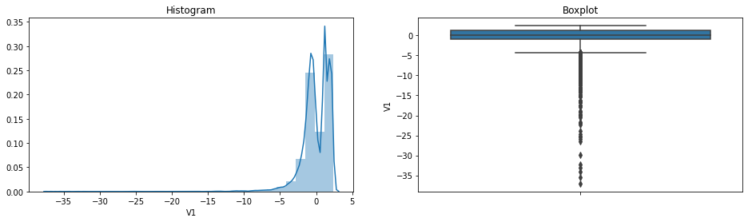

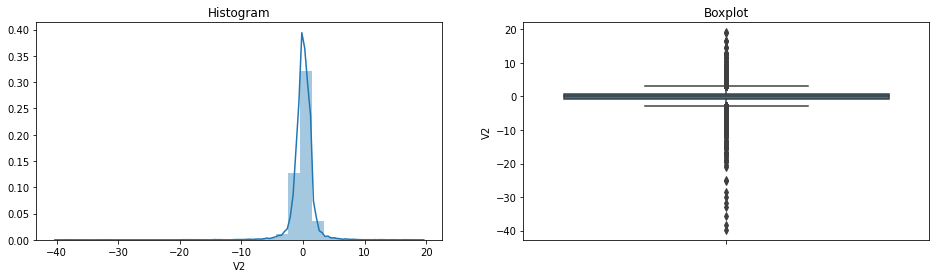

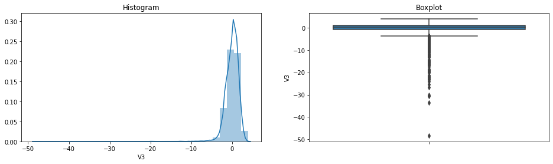

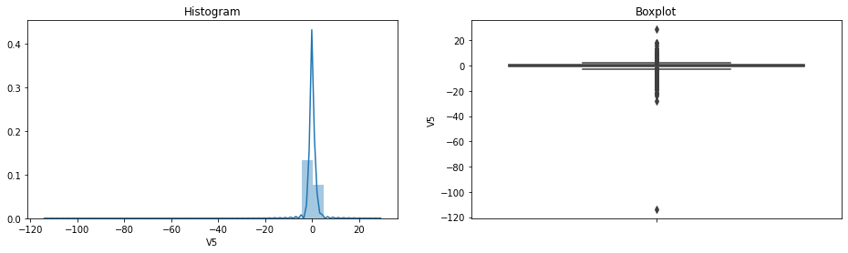

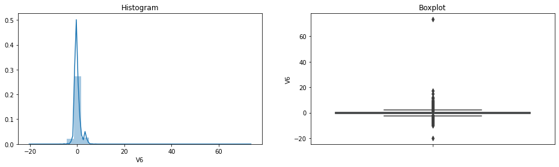

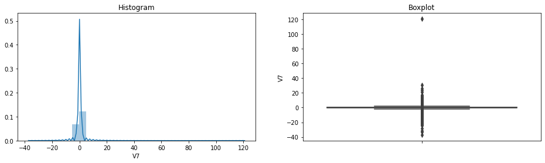

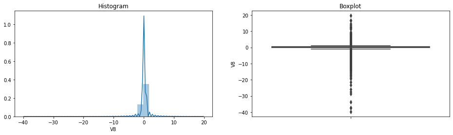

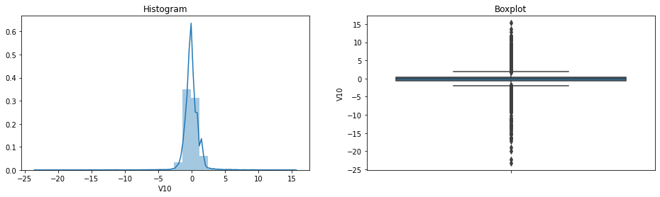

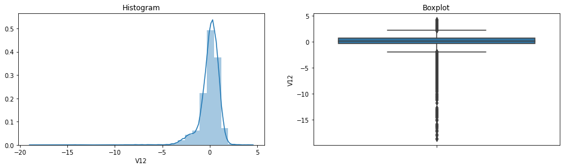

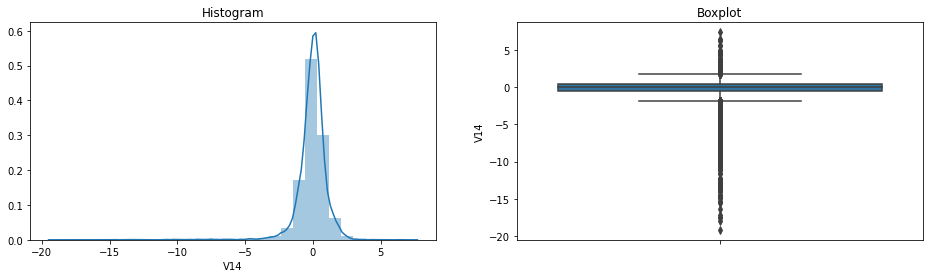

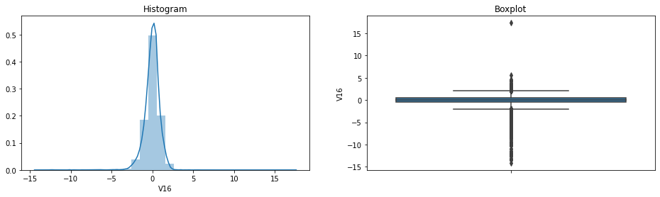

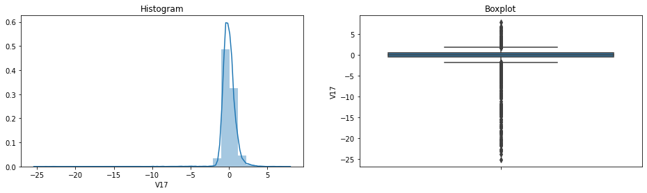

[8 more figures not shown]

```python
# Use the above function for visualizing numerical variables

for var in continuous:
    diagnostic_plots(data, var)
```

```python
## many variables doesnt follow normal distribution and have outliers
```

```python
transformation_needed='V1 V2 V3  V5 V6 V7 V8 V10 V12 V14 V16 V17 V20 V21 V23 V24 V26 V27 V28 V29'.split()
```

```python
!pip install feature_engine
# from feature-engine
from feature_engine import missing_data_imputers as mdi
# for one hot encoding with feature-engine
from feature_engine.categorical_encoders import OneHotCategoricalEncoder
from feature_engine.variable_transformers import YeoJohnsonTransformer as YJT
from sklearn.preprocessing import RobustScaler
from sklearn.pipeline import Pipeline
# to impute missing data with feature-engine
from feature_engine.missing_data_imputers import FrequentCategoryImputer
```

# Preprocessing

```python
from sklearn.model_selection import train_test_split
X_trainval, X_test, y_trainval, y_test = train_test_split(data.drop('Target',axis=1), data['Target'], test_size=0.2, random_state=0)
X_train, X_val, y_train, y_val = train_test_split(X_trainval, y_trainval, test_size=0.25, random_state=0)
```

```python
print(f'Train size is {X_train.shape}' )
print(f'Test size is {X_test.shape}' )
print(f'Val size is {X_val.shape}' )
```

```
Train size is (14907, 30)
Test size is (4970, 30)
Val size is (4969, 30)
```

imputing the misssing values and transforming the variables which will help in bringing the distrubution to normal and limit the outliers

```python
life_pipeline=Pipeline([
    ('median_imputer',mdi.MeanMedianImputer(imputation_method='median',
                                   variables=continuous)),
   ('power_transform',YJT()),   #transforms variables as most of the variables are not in normal this also fixes some of the outliers
   ('scale',RobustScaler())  ,     #scalling the values
])
```

```python
life_pipeline.fit(X_train,y_train)
```

```
Pipeline(memory=None,
         steps=[('median_imputer',
                 MeanMedianImputer(imputation_method='median',
                                   variables=['V1', 'V2', 'V3', 'V4', 'V5',
                                              'V6', 'V7', 'V8', 'V9', 'V10',
                                              'V11', 'V12', 'V13', 'V14', 'V15',
                                              'V16', 'V17', 'V18', 'V19', 'V20',
                                              'V21', 'V22', 'V23', 'V24', 'V25',
                                              'V26', 'V27', 'V28', 'V29'])),
                ('power_transform',
                 YeoJohnsonTransformer(variables=['Id', 'V1', 'V2', 'V3', 'V4',
                                                  'V5', 'V6', 'V7', 'V8', 'V9',
                                                  'V10', 'V11', 'V12', 'V13',
                                                  'V14', 'V15', 'V16', 'V17',
                                                  'V18', 'V19', 'V20', 'V21',
                                                  'V22', 'V23', 'V24', 'V25',
                                                  'V26', 'V27', 'V28',
                                                  'V29'])),
                ('scale',
                 RobustScaler(copy=True, quantile_range=(25.0, 75.0),
                              with_centering=True, with_scaling=True))],
         verbose=False)
```

```python
X_train=life_pipeline.transform(X_train)
X_test=life_pipeline.transform(X_test)
X_val=life_pipeline.transform(X_val)
```

```python
test = life_pipeline.transform(test)
```

```python
# using pickle to store , by this we need not run all the above steps again and again for different models, pickle is also used to store models

pickle.dump( X_val, open( "/content/drive/My Drive/X_val.p", "wb" ) )
pickle.dump( X_test, open( "/content/drive/My Drive/X_test.p", "wb" ) )
pickle.dump( X_train, open( "/content/drive/My Drive/X_train.p", "wb" ) )
pickle.dump( test, open( "/content/drive/My Drive/test.p", "wb" ) )
pickle.dump( y_train, open( "/content/drive/My Drive/y_train.p", "wb" ) )
pickle.dump( y_val, open( "/content/drive/My Drive/y_val.p", "wb" ) )
pickle.dump( y_test, open( "/content/drive/My Drive/y_test.p", "wb" ) )
```

# test train val

```python
X_train = pickle.load( open( "/content/drive/My Drive/X_train.p", "rb" ) )
X_test = pickle.load( open( "/content/drive/My Drive/X_test.p", "rb" ) )
X_val = pickle.load( open( "/content/drive/My Drive/X_val.p", "rb" ) )
test = pickle.load( open( "/content/drive/My Drive/test.p", "rb" ) )
y_train = pickle.load( open( "/content/drive/My Drive/y_train.p", "rb" ) )
y_val = pickle.load( open( "/content/drive/My Drive/y_val.p", "rb" ) )
y_test = pickle.load( open( "/content/drive/My Drive/y_test.p", "rb" ) )
```

# base models

## naive model

```python
# Naive Algorithm
from sklearn.dummy import DummyClassifier
from sklearn.model_selection import cross_val_score
model_dummy = DummyClassifier(random_state=123 )

dummy_param = {'strategy': ["stratified","prior","uniform"]
               }
dummy_grid = GridSearchCV(model_dummy, dummy_param,cv=5, return_train_score=True,scoring='f1' )
dummy_grid.fit(X_train,y_train)

# Check test data set performance
print("Naive Algorithm best mean cv score: ", dummy_grid.best_score_)
print("Naive Algorithm test score: ", dummy_grid.score(X_test,y_test))
print("Naive Algorithm train Performance: ", dummy_grid.score(X_train,y_train))
print("Naive Algorithm val Performance: ", dummy_grid.score(X_val,y_val))
print("Naive Algorithm best parm: ", dummy_grid.best_params_)
```

```
Naive Algorithm best mean cv score:  0.02184368110953104
Naive Algorithm test score:  0.027037773359840953
Naive Algorithm train Performance:  0.019080429309659464
Naive Algorithm val Performance:  0.02070063694267516
Naive Algorithm best parm:  {'strategy': 'uniform'}
```

## Logistic Regression

```python
logreg=LogisticRegression(max_iter=10000)

logreg_param = {'C': loguniform(1e-3, 1e3),
               'solver' : ['liblinear'] ,
               'penalty':['l1','l2'],
              # 'l1_ratio': loguniform(1e-2, 1e0)
               }
logreg_rand = RandomizedSearchCV(logreg, logreg_param,cv=5, return_train_score=True,scoring='f1' )
logreg_rand.fit(X_train,y_train)
```

```
RandomizedSearchCV(cv=5, error_score=nan,
                   estimator=LogisticRegression(C=1.0, class_weight=None,
                                                dual=False, fit_intercept=True,
                                                intercept_scaling=1,
                                                l1_ratio=None, max_iter=10000,
                                                multi_class='auto', n_jobs=None,
                                                penalty='l2', random_state=None,
                                                solver='lbfgs', tol=0.0001,
                                                verbose=0, warm_start=False),
                   iid='deprecated', n_iter=10, n_jobs=None,
                   param_distributions={'C': <scipy.stats._distn_infrastructure.rv_frozen object at 0x7f459c76dcc0>,
                                        'penalty': ['l1', 'l2'],
                                        'solver': ['liblinear']},
                   pre_dispatch='2*n_jobs', random_state=None, refit=True,
                   return_train_score=True, scoring='f1', verbose=0)
```

```python
print(f'Best Mean Cross Validation Score is {logreg_rand.best_score_}')
print(f'Best Parameters: {logreg_rand.best_params_}')
print(f'Train score is {logreg_rand.score(X_train,y_train)}')
print(f'Test score is {logreg_rand.score(X_test,y_test)}')
print(f'Val score is {logreg_rand.score(X_val,y_val)}')
```

```
Best Mean Cross Validation Score is 0.872792737414269
Best Parameters: {'C': 0.02867846983550828, 'penalty': 'l2', 'solver': 'liblinear'}
Train score is 0.8725868725868726
Test score is 0.8297872340425531
Val score is 0.8791208791208791
```

```python
pickle.dump( logreg_rand, open( "/content/drive/My Drive/logreg_rand.p", "wb" ) )
```

## KNN

```python
from sklearn.neighbors import KNeighborsClassifier
knn= KNeighborsClassifier()

knn_param= { 'n_neighbors' : range(2,20), 'weights': ['uniform','distance']}
knn_Rand = RandomizedSearchCV(knn, knn_param,cv=5, return_train_score=True,scoring='f1' )
knn_Rand.fit(X_train,y_train)
```

```
RandomizedSearchCV(cv=5, error_score=nan,
                   estimator=KNeighborsClassifier(algorithm='auto',
                                                  leaf_size=30,
                                                  metric='minkowski',
                                                  metric_params=None,
                                                  n_jobs=None, n_neighbors=5,
                                                  p=2, weights='uniform'),
                   iid='deprecated', n_iter=10, n_jobs=None,
                   param_distributions={'n_neighbors': range(2, 20),
                                        'weights': ['uniform', 'distance']},
                   pre_dispatch='2*n_jobs', random_state=None, refit=True,
                   return_train_score=True, scoring='f1', verbose=0)
```

```python
print(f'Best Mean Cross Validation Score is {knn_Rand.best_score_}')
print(f'Best Parameters : {knn_Rand.best_params_}')
print(f'Train score is {knn_Rand.score(X_train,y_train)}')
print(f'Test score is {knn_Rand.score(X_test,y_test)}')
print(f'Validation score is {knn_Rand.score(X_val,y_val)}')
```

```
Best Mean Cross Validation Score is 0.832679497696725
Best Parameters : {'weights': 'distance', 'n_neighbors': 7}
Train score is 1.0
Test score is 0.7777777777777778
Validation score is 0.8764044943820225
```

```python
pickle.dump( knn_Rand, open( "/content/drive/My Drive/knn_Rand.p", "wb" ) )
```

```python
knn_Rand= pickle.load( open( "/content/drive/My Drive/knn_Rand.p", "rb" ) )
```

## SVC

### Linear

```python
from sklearn.svm import SVC
```

```python
lsvc=SVC(kernel='linear',probability=True)
lsvc_param= {'C': [0.8,1,2],}
lsvc_grid = GridSearchCV(lsvc, lsvc_param,cv=5, return_train_score=True,scoring='f1' )
lsvc_grid.fit(X_train,y_train)
```

```
GridSearchCV(cv=5, error_score=nan,
             estimator=SVC(C=1.0, break_ties=False, cache_size=200,
                           class_weight=None, coef0=0.0,
                           decision_function_shape='ovr', degree=3,
                           gamma='scale', kernel='linear', max_iter=-1,
                           probability=True, random_state=None, shrinking=True,
                           tol=0.001, verbose=False),
             iid='deprecated', n_jobs=None, param_grid={'C': [0.8, 1, 2]},
             pre_dispatch='2*n_jobs', refit=True, return_train_score=True,
             scoring='f1', verbose=0)
```

```python
print(f'Best Mean Cross Validation Score is {lsvc_grid.best_score_}')
print(f'Best Parameters: {lsvc_grid.best_params_}')
print(f'Train score is {lsvc_grid.score(X_train,y_train)}')
print(f'Test score is {lsvc_grid.score(X_test,y_test)}')
print(f'Val score is {lsvc_grid.score(X_val,y_val)}')
```

```
Best Mean Cross Validation Score is 0.8735165295920012
Best Parameters: {'C': 0.8}
Train score is 0.8735632183908046
Test score is 0.8297872340425531
Val score is 0.8913043478260869
```

```python
pickle.dump( lsvc_grid, open( "/content/drive/My Drive/lsvc_grid.p", "wb" ) )
```

```python
lsvc_grid = pickle.load( open( "/content/drive/My Drive/lsvc_grid.p", "rb" ) )
```

### lsvc

```python
lsvc=SVC(kernel='linear',probability=True)
lsvc_param= {'C':loguniform(1e-4, 1e+3),}
lsvc_rand = RandomizedSearchCV(lsvc, lsvc_param,cv=5, return_train_score=True,scoring='f1' )
lsvc_rand.fit(X_train,y_train)
```

```
RandomizedSearchCV(cv=5, error_score=nan,
                   estimator=SVC(C=1.0, break_ties=False, cache_size=200,
                                 class_weight=None, coef0=0.0,
                                 decision_function_shape='ovr', degree=3,
                                 gamma='scale', kernel='linear', max_iter=-1,
                                 probability=True, random_state=None,
                                 shrinking=True, tol=0.001, verbose=False),
                   iid='deprecated', n_iter=10, n_jobs=None,
                   param_distributions={'C': <scipy.stats._distn_infrastructure.rv_frozen object at 0x7f87a4181320>},
                   pre_dispatch='2*n_jobs', random_state=None, refit=True,
                   return_train_score=True, scoring='f1', verbose=0)
```

```python
print(f'Best Mean Cross Validation Score is {lsvc_rand.best_score_}')
print(f'Best Parameters: {lsvc_rand.best_params_}')
print(f'Train score is {lsvc_rand.score(X_train,y_train)}')
print(f'Test score is {lsvc_rand.score(X_test,y_test)}')
print(f'Val score is {lsvc_rand.score(X_val,y_val)}')
```

```
Best Mean Cross Validation Score is 0.8735165295920012
Best Parameters: {'C': 6.487454192137668}
Train score is 0.8735632183908046
Test score is 0.8297872340425531
Val score is 0.8913043478260869
```

```python
pickle.dump( lsvc_rand, open( "/content/drive/My Drive/lsvc_rand.p", "wb" ) )
```

```python
lsvc_rand = pickle.load( open( "/content/drive/My Drive/lsvc_rand.p", "rb" ) )
```

### kernal

```python
from sklearn.svm import SVC
```

#### Rbf grid

```python
ksvc=SVC(probability=True)
ksvcRbf_param = [{'kernel': ['rbf'],
               'C': [1,5,10],
               'gamma': [.001,.0005,.0001]},
                ]

ksvcRbf_grid = GridSearchCV(ksvc, ksvcRbf_param ,cv=3, return_train_score=True, scoring='f1',n_jobs=-1)
```

```python
ksvcRbf_grid.fit(X_train,y_train)
```

```
GridSearchCV(cv=3, error_score=nan,
             estimator=SVC(C=1.0, break_ties=False, cache_size=200,
                           class_weight=None, coef0=0.0,
                           decision_function_shape='ovr', degree=3,
                           gamma='scale', kernel='rbf', max_iter=-1,
                           probability=True, random_state=None, shrinking=True,
                           tol=0.001, verbose=False),
             iid='deprecated', n_jobs=-1,
             param_grid=[{'C': [1, 5, 10], 'gamma': [0.001, 0.0005, 0.0001],
                          'kernel': ['rbf']}],
             pre_dispatch='2*n_jobs', refit=True, return_train_score=True,
             scoring='f1', verbose=0)
```

```python
print(f'Best Mean Cross Validation Score is {ksvcRbf_grid.best_score_}')
print(f'Best Parameters: {ksvcRbf_grid.best_params_}')
print(f'Train score is {ksvcRbf_grid.score(X_train,y_train)}')
print(f'Test score is {ksvcRbf_grid.score(X_test,y_test)}')
print(f'Val score is {ksvcRbf_grid.score(X_val,y_val)}')
```

```
Best Mean Cross Validation Score is 0.8767687953734465
Best Parameters: {'C': 10, 'gamma': 0.0001, 'kernel': 'rbf'}
Train score is 0.8735632183908046
Test score is 0.8297872340425531
Val score is 0.8913043478260869
```

```python
pickle.dump( ksvcRbf_grid, open( "/content/drive/My Drive/ksvcRbf_grid.p", "wb" ) )
```

```python
ksvcRbf_grid = pickle.load( open( "/content/drive/My Drive/ksvcRbf_grid.p", "rb" ) )
```

#### Kernal Sigmoid

```python
ksvc=SVC(probability=True)
ksvcSigm_param = [

             {'kernel': ['sigmoid'],
               'C': [1,5,10],
               'gamma': [0.0001,.0005]}]

ksvcSigm_grid = GridSearchCV(ksvc, ksvcSigm_param,cv=5, return_train_score=True, scoring='f1')
ksvcSigm_grid.fit(X_train,y_train)
```

[output not shown]

```python
print(f'Best Mean Cross Validation Score is {ksvcSigm_grid.best_score_}')
print(f'Best Parameters: {ksvcSigm_grid.best_params_}')
print(f'Train score is {ksvcSigm_grid.score(X_train,y_train)}')
print(f'Test score is {ksvcSigm_grid.score(X_test,y_test)}')
print(f'Val score is {ksvcSigm_grid.score(X_val,y_val)}')
```

```
Best Mean Cross Validation Score is 0.872792737414269
Best Parameters: {'C': 10, 'gamma': 0.0001, 'kernel': 'sigmoid'}
Train score is 0.8659003831417624
Test score is 0.8172043010752688
Val score is 0.8913043478260869
```

```python
pickle.dump( ksvcSigm_grid, open( "/content/drive/My Drive/ksvcSigm_grid.p", "wb" ) )
```

```python
ksvcSigm_grid = pickle.load( open( "/content/drive/My Drive/ksvcSigm_grid.p", "rb" ) )
```

## Random forest

```python
rfc =RandomForestClassifier(random_state=42)
rfc_param = {
     'n_estimators': [300],
    'max_features': ['auto'],
    'max_depth' : range(2,10),
    'criterion' :['entropy']
}

rfc_grid2 = GridSearchCV(rfc, rfc_param,cv=5, return_train_score=True,scoring='f1' )
rfc_grid2.fit(X_train,y_train)
```

```
GridSearchCV(cv=5, error_score=nan,
             estimator=RandomForestClassifier(bootstrap=True, ccp_alpha=0.0,
                                              class_weight=None,
                                              criterion='gini', max_depth=None,
                                              max_features='auto',
                                              max_leaf_nodes=None,
                                              max_samples=None,
                                              min_impurity_decrease=0.0,
                                              min_impurity_split=None,
                                              min_samples_leaf=1,
                                              min_samples_split=2,
                                              min_weight_fraction_leaf=0.0,
                                              n_estimators=100, n_jobs=None,
                                              oob_score=False, random_state=42,
                                              verbose=0, warm_start=False),
             iid='deprecated', n_jobs=None,
             param_grid={'criterion': ['entropy'], 'max_depth': range(2, 10),
                         'max_features': ['auto'], 'n_estimators': [300]},
             pre_dispatch='2*n_jobs', refit=True, return_train_score=True,
             scoring='f1', verbose=0)
```

```python
print(f'Best Mean Cross Validation Score is {rfc_grid2.best_score_}')
print(f'Best Parameters: {rfc_grid2.best_params_}')
print(f'Train score is {rfc_grid2.score(X_train,y_train)}')
print(f'Test score is {rfc_grid2.score(X_test,y_test)}')
print(f'Val score is {rfc_grid2.score(X_val,y_val)}')
```

```
Best Mean Cross Validation Score is 0.8867405952866552
Best Parameters: {'criterion': 'entropy', 'max_depth': 9, 'max_features': 'auto', 'n_estimators': 300}
Train score is 0.9516728624535316
Test score is 0.865979381443299
Val score is 0.8817204301075269
```

```python
pickle.dump( rfc_grid2, open( "/content/drive/My Drive/rfc_grid2.p", "wb" ) )
```

```python
rfc_grid2 = pickle.load( open( "/content/drive/My Drive/rfc_grid2.p", "rb" ) )
```

## Extra trees

```python
etc= ExtraTreesClassifier(random_state=42)
etc_param = {
   # 'n_estimators': [300,500,800],
    'max_features': ['log2'],
    'max_depth' : range(18,30,2),
    'criterion' :['gini']
}
etc_grid = GridSearchCV(etc, etc_param,cv=5, return_train_score=True,scoring='f1' )
etc_grid.fit(X_train,y_train)
```

```
GridSearchCV(cv=5, error_score=nan,
             estimator=ExtraTreesClassifier(bootstrap=False, ccp_alpha=0.0,
                                            class_weight=None, criterion='gini',
                                            max_depth=None, max_features='auto',
                                            max_leaf_nodes=None,
                                            max_samples=None,
                                            min_impurity_decrease=0.0,
                                            min_impurity_split=None,
                                            min_samples_leaf=1,
                                            min_samples_split=2,
                                            min_weight_fraction_leaf=0.0,
                                            n_estimators=100, n_jobs=None,
                                            oob_score=False, random_state=42,
                                            verbose=0, warm_start=False),
             iid='deprecated', n_jobs=None,
             param_grid={'criterion': ['gini'], 'max_depth': range(18, 30, 2),
                         'max_features': ['log2']},
             pre_dispatch='2*n_jobs', refit=True, return_train_score=True,
             scoring='f1', verbose=0)
```

```python
print(f'Best Mean Cross Validation Score is {etc_grid.best_score_}')
print(f'Best Parameters: {etc_grid.best_params_}')
print(f'Train score is {etc_grid.score(X_train,y_train)}')
print(f'Test score is {etc_grid.score(X_test,y_test)}')
print(f'Val score is {etc_grid.score(X_val,y_val)}')
```

```
Best Mean Cross Validation Score is 0.8726147142617731
Best Parameters: {'criterion': 'gini', 'max_depth': 22, 'max_features': 'log2'}
Train score is 0.9964412811387899
Test score is 0.8421052631578947
Val score is 0.9010989010989011
```

```python
pickle.dump( etc_grid, open( "/content/drive/My Drive/etc_grid.p", "wb" ) )
```

```python
etc_grid = pickle.load( open( "/content/drive/My Drive/etc_grid.p", "rb" ) )
```

## xgb ran

```python
from  xgboost import XGBClassifier
xgbc= XGBClassifier(random_state=42,early_stopping_rounds=2,objective= 'binary:logistic')
xgbc_param = {
              'max_depth' : [8,12,15],
              #'n_estimators' : [100,120,150],
              'learning_rate' : loguniform(1e-3,1e3),
              # 'min_child_weight' : [1,3],
                'subsample': loguniform(1e-3,1e0)
             }
xgbc_rand = RandomizedSearchCV(xgbc, xgbc_param,cv=5, return_train_score=True,scoring='f1',n_iter=10 )
xgbc_rand.fit(X_train,y_train)
```

```
RandomizedSearchCV(cv=5, error_score=nan,
                   estimator=XGBClassifier(base_score=0.5, booster='gbtree',
                                           colsample_bylevel=1,
                                           colsample_bynode=1,
                                           colsample_bytree=1,
                                           early_stopping_rounds=2, gamma=0,
                                           learning_rate=0.1, max_delta_step=0,
                                           max_depth=3, min_child_weight=1,
                                           missing=None, n_estimators=100,
                                           n_jobs=1, nthread=None,
                                           objective='binary:logistic',
                                           random_state=42, re...
                                           verbosity=1),
                   iid='deprecated', n_iter=10, n_jobs=None,
                   param_distributions={'learning_rate': <scipy.stats._distn_infrastructure.rv_frozen object at 0x7f1450cf1240>,
                                        'max_depth': [8, 12, 15],
                                        'subsample': <scipy.stats._distn_infrastructure.rv_frozen object at 0x7f1450ceb630>},
                   pre_dispatch='2*n_jobs', random_state=None, refit=True,
                   return_train_score=True, scoring='f1', verbose=0)
```

```python
print(f'Best Mean Cross Validation Score is {xgbc_rand.best_score_}')
print(f'Best Parameters: {xgbc_rand.best_params_}')
print(f'Train score is {xgbc_rand.score(X_train,y_train)}')
print(f'Test score is {xgbc_rand.score(X_test,y_test)}')
print(f'Val score is {xgbc_rand.score(X_val,y_val)}')
```

```
Best Mean Cross Validation Score is 0.8828576036123206
Best Parameters: {'learning_rate': 0.019424950245585725, 'max_depth': 15, 'subsample': 0.9088870306683204}
Train score is 0.9166666666666667
Test score is 0.8571428571428572
Val score is 0.8865979381443299
```

```python
pickle.dump( xgbc_rand, open( "/content/drive/My Drive/xgbc_rand.p", "wb" ) )
```

```python
xgbc_rand = pickle.load( open( "/content/drive/My Drive/xgbc_rand.p", "rb" ) )
```

### sbg *penalty*

```python
from  xgboost import XGBClassifier
xgbc= XGBClassifier(random_state=42,early_stopping_rounds=2,objective= 'binary:logistic')
xgbc_param = {
              'max_depth' : [12],
              #'n_estimators' : [100,120,150],
             # 'learning_rate' : [.001,.05],
              # 'min_child_weight' : [1,3],
               # 'subsample': loguniform(1e-3,1e0)
               'reg_alpha' : [.8]
             }
xgbc_grid4 = GridSearchCV(xgbc, xgbc_param,cv=5, return_train_score=True,scoring='f1',)
xgbc_grid4.fit(X_train,y_train)
```

```
GridSearchCV(cv=5, error_score=nan,
             estimator=XGBClassifier(base_score=0.5, booster='gbtree',
                                     colsample_bylevel=1, colsample_bynode=1,
                                     colsample_bytree=1,
                                     early_stopping_rounds=2, gamma=0,
                                     learning_rate=0.1, max_delta_step=0,
                                     max_depth=3, min_child_weight=1,
                                     missing=None, n_estimators=100, n_jobs=1,
                                     nthread=None, objective='binary:logistic',
                                     random_state=42, reg_alpha=0, reg_lambda=1,
                                     scale_pos_weight=1, seed=None, silent=None,
                                     subsample=1, verbosity=1),
             iid='deprecated', n_jobs=None,
             param_grid={'max_depth': [12], 'reg_alpha': [0.8]},
             pre_dispatch='2*n_jobs', refit=True, return_train_score=True,
             scoring='f1', verbose=0)
```

```python
print(f'Best Mean Cross Validation Score is {xgbc_grid4.best_score_}')
print(f'Best Parameters: {xgbc_grid4.best_params_}')
print(f'Train score is {xgbc_grid4.score(X_train,y_train)}')
print(f'Test score is {xgbc_grid4.score(X_test,y_test)}')
print(f'Val score is {xgbc_grid4.score(X_val,y_val)}')
```

```
Best Mean Cross Validation Score is 0.8972063329444018
Best Parameters: {'max_depth': 12, 'reg_alpha': 0.8}
Train score is 0.9747292418772563
Test score is 0.8541666666666667
Val score is 0.8842105263157894
```

```python
pickle.dump( xgbc_grid4, open( "/content/drive/My Drive/xgbc_grid4.p", "wb" ) )
```

```python
xgbc_grid4 = pickle.load( open( "/content/drive/My Drive/xgbc_grid4.p", "rb" ) )

lsvc_grid = pickle.load( open( "/content/drive/My Drive/lsvc_grid.p", "rb" ) )
knn_Rand= pickle.load( open( "/content/drive/My Drive/knn_Rand.p", "rb" ) )
logreg_rand= pickle.load( open( "/content/drive/My Drive/logreg_rand.p", "rb" ) )
lsvc_rand = pickle.load( open( "/content/drive/My Drive/lsvc_rand.p", "rb" ) )
ksvcRbf_grid = pickle.load( open( "/content/drive/My Drive/ksvcRbf_grid.p", "rb" ) )
ksvcSigm_grid = pickle.load( open( "/content/drive/My Drive/ksvcSigm_grid.p", "rb" ) )
rfc_grid2 = pickle.load( open( "/content/drive/My Drive/rfc_grid2.p", "rb" ) )
etc_grid = pickle.load( open( "/content/drive/My Drive/etc_grid.p", "rb" ) )
xgbc_rand = pickle.load( open( "/content/drive/My Drive/xgbc_rand.p", "rb" ) )
xgbc_grid4 = pickle.load( open( "/content/drive/My Drive/xgbc_grid4.p", "rb" ) )
```

## summary for basic

```python
classifiers_basic ={
                         'logreg_rand':logreg_rand ,
                         'knn_Rand':knn_Rand ,
                      #   'lsvc_rand':lsvc_rand,
                    'lsvc_grid':lsvc_grid,
                         'ksvcRbf_grid':ksvcRbf_grid,
                         'ksvcSigm_grid':ksvcSigm_grid,

                   'rfc_grid2':rfc_grid2,
                         'etc_grid': etc_grid,
                        'xgbc_grid4':xgbc_grid4,
                                      }
```

```python
classifiers_basic.keys()
```

```
dict_keys(['logreg_rand', 'knn_Rand', 'lsvc_grid', 'ksvcRbf_grid', 'ksvcSigm_grid', 'rfc_grid2', 'etc_grid', 'xgbc_grid4'])
```

```python
results_mean_std = []
for  key, value in classifiers_basic.items():
    mean = value.cv_results_['mean_test_score'][value.best_index_]
    std=value.cv_results_['std_test_score'][value.best_index_]

    results_mean_std.append({
        "model": key,
        "mean": mean,
        "std": std
    })
```

```python
accuracy_basic_df = pd.DataFrame(results_mean_std, columns=['model', 'mean', 'std'])
```

```python
# Show the accuracy dataframe

accuracy_basic_df.sort_values(by=['mean'], inplace=True,ascending=False)
accuracy_basic_df
```

|  | model | mean | std |
| --- | --- | --- | --- |
| 7 | xgbc_grid4 | 0.897206 | 0.020342 |
| 5 | rfc_grid2 | 0.886741 | 0.025011 |
| 3 | ksvcRbf_grid | 0.876769 | 0.011975 |
| 2 | lsvc_grid | 0.873517 | 0.015372 |
| 0 | logreg_rand | 0.872793 | 0.018219 |
| 4 | ksvcSigm_grid | 0.872793 | 0.018219 |
| 6 | etc_grid | 0.872615 | 0.033423 |
| 1 | knn_Rand | 0.832679 | 0.049841 |

```python
pickle.dump( accuracy_basic_df, open( "/content/drive/My Drive/accuracy_basic_df.p", "wb" ) )
```

# Cost Sensitive Algorithms

## Cost Sensitive Logistic regression

```python
logreg = LogisticRegression(solver='lbfgs')
param_grid = {

    'class_weight': [{0:100,1:1}, {0:10,1:1}, {0:1,1:1}, {0:1,1:10}, {0:1,1:100}],
     'C': [.01,4,5,6]
}

#apply grid search
clogreg_grid= GridSearchCV(logreg, param_grid, cv=5, n_jobs=2, scoring='f1')
clogreg_grid.fit(X_train, y_train)
```

```
GridSearchCV(cv=5, error_score=nan,
             estimator=LogisticRegression(C=1.0, class_weight=None, dual=False,
                                          fit_intercept=True,
                                          intercept_scaling=1, l1_ratio=None,
                                          max_iter=100, multi_class='auto',
                                          n_jobs=None, penalty='l2',
                                          random_state=None, solver='lbfgs',
                                          tol=0.0001, verbose=0,
                                          warm_start=False),
             iid='deprecated', n_jobs=2,
             param_grid={'C': [0.01, 4, 5, 6],
                         'class_weight': [{0: 100, 1: 1}, {0: 10, 1: 1},
                                          {0: 1, 1: 1}, {0: 1, 1: 10},
                                          {0: 1, 1: 100}]},
             pre_dispatch='2*n_jobs', refit=True, return_train_score=False,
             scoring='f1', verbose=0)
```

```python
print(f'Best Mean Cross Validation Score is {clogreg_grid.best_score_}')
print(f'Best Parameters: {clogreg_grid.best_params_}')
print(f'Train score is {clogreg_grid.score(X_train,y_train)}')
print(f'Test score is {clogreg_grid.score(X_test,y_test)}')
print(f'Val score is {clogreg_grid.score(X_val,y_val)}')
```

```
Best Mean Cross Validation Score is 0.8565946036534271
Best Parameters: {'C': 4, 'class_weight': {0: 1, 1: 1}}
Train score is 0.8769230769230768
Test score is 0.8421052631578947
Val score is 0.8695652173913043
```

```python
pickle.dump( clogreg_grid, open( "/content/drive/My Drive/clogreg_grid.p", "wb" ) )
```

## Cost Sensitive Decison Tree

```python
dtree = DecisionTreeClassifier()
param_grid = {

    'class_weight': [{0:100,1:1}, {0:10,1:1}, {0:1,1:1}, {0:1,1:10}, {0:1,1:100}],
    "max_depth": range(1,10),
    "min_samples_split": range(2,10,1),
    "max_leaf_nodes": range(2,6),
    "splitter": ["best", "random"]
}

#apply grid search
cdtree_rand= RandomizedSearchCV(dtree, param_grid, cv=5, n_jobs=2, scoring='f1',n_iter = 20)
cdtree_rand.fit(X_train, y_train)
```

```
RandomizedSearchCV(cv=5, error_score=nan,
                   estimator=DecisionTreeClassifier(ccp_alpha=0.0,
                                                    class_weight=None,
                                                    criterion='gini',
                                                    max_depth=None,
                                                    max_features=None,
                                                    max_leaf_nodes=None,
                                                    min_impurity_decrease=0.0,
                                                    min_impurity_split=None,
                                                    min_samples_leaf=1,
                                                    min_samples_split=2,
                                                    min_weight_fraction_leaf=0.0,
                                                    presort='deprecated',
                                                    random_state=None,
                                                    splitter='best'),
                   iid='deprecated', n_iter=20, n_jobs=2,
                   param_distributions={'class_weight': [{0: 100, 1: 1},
                                                         {0: 10, 1: 1},
                                                         {0: 1, 1: 1},
                                                         {0: 1, 1: 10},
                                                         {0: 1, 1: 100}],
                                        'max_depth': range(1, 10),
                                        'max_leaf_nodes': range(2, 6),
                                        'min_samples_split': range(2, 10),
                                        'splitter': ['best', 'random']},
                   pre_dispatch='2*n_jobs', random_state=None, refit=True,
                   return_train_score=False, scoring='f1', verbose=0)
```

```python
print(f'Best Mean Cross Validation Score is {cdtree_rand.best_score_}')
print(f'Best Parameters: {cdtree_rand.best_params_}')
print(f'Train score is {cdtree_rand.score(X_train,y_train)}')
print(f'Test score is {cdtree_rand.score(X_test,y_test)}')
print(f'Val score is {cdtree_rand.score(X_val,y_val)}')
```

```
Best Mean Cross Validation Score is 0.8670570021912974
Best Parameters: {'splitter': 'best', 'min_samples_split': 7, 'max_leaf_nodes': 3, 'max_depth': 8, 'class_weight': {0: 1, 1: 1}}
Train score is 0.8803088803088803
Test score is 0.7415730337078651
Val score is 0.8478260869565217
```

```python
pickle.dump( cdtree_rand, open( "/content/drive/My Drive/cdtree_rand.p", "wb" ) )
```

```python
dtree = DecisionTreeClassifier()
param_grid = {

    'class_weight': [{0:100,1:1}, {0:10,1:1}, {0:1,1:1}, {0:1,1:10}, {0:1,1:100}],
    "max_depth": range(2,10,),
    "min_samples_split": range(2,10,),
    "max_leaf_nodes": range(2,6),
    "splitter": ["best", "random"],
     'max_features': ['auto', 'sqrt', 'log2']
}

#apply grid search
cdtree_grid= GridSearchCV(dtree, param_grid, cv=5, n_jobs=2, scoring='f1')
cdtree_grid.fit(X_train, y_train)
```

```
GridSearchCV(cv=5, error_score=nan,
             estimator=DecisionTreeClassifier(ccp_alpha=0.0, class_weight=None,
                                              criterion='gini', max_depth=None,
                                              max_features=None,
                                              max_leaf_nodes=None,
                                              min_impurity_decrease=0.0,
                                              min_impurity_split=None,
                                              min_samples_leaf=1,
                                              min_samples_split=2,
                                              min_weight_fraction_leaf=0.0,
                                              presort='deprecated',
                                              random_state=None,
                                              splitter='best'),
             iid='deprecated', n_jobs=2,
             param_grid={'class_weight': [{0: 100, 1: 1}, {0: 10, 1: 1},
                                          {0: 1, 1: 1}, {0: 1, 1: 10},
                                          {0: 1, 1: 100}],
                         'max_depth': range(2, 10),
                         'max_features': ['auto', 'sqrt', 'log2'],
                         'max_leaf_nodes': range(2, 6),
                         'min_samples_split': range(2, 10),
                         'splitter': ['best', 'random']},
             pre_dispatch='2*n_jobs', refit=True, return_train_score=False,
             scoring='f1', verbose=0)
```

```python
print(f'Best Mean Cross Validation Score is {cdtree_grid.best_score_}')
print(f'Best Parameters: {cdtree_grid.best_params_}')
print(f'Train score is {cdtree_grid.score(X_train,y_train)}')
print(f'Test score is {cdtree_grid.score(X_test,y_test)}')
print(f'Val score is {cdtree_grid.score(X_val,y_val)}')
```

```
Best Mean Cross Validation Score is 0.8604057673383819
Best Parameters: {'class_weight': {0: 1, 1: 1}, 'max_depth': 5, 'max_features': 'sqrt', 'max_leaf_nodes': 4, 'min_samples_split': 7, 'splitter': 'best'}
Train score is 0.8181818181818182
Test score is 0.625
Val score is 0.813953488372093
```

```python
pickle.dump( cdtree_grid, open( "/content/drive/My Drive/cdtree_grid.p", "wb" ) )
```

## Cost Sensitive SVM

### Linear

```python
lsvc=SVC(kernel='linear',probability=True)
lsvc_param= {'C':loguniform(1e-4, 1e+3),
              'class_weight': [{0:100,1:1}, {0:10,1:1}, {0:1,1:1}, {0:1,1:10}, {0:1,1:100},'balanced'],

             }
clsvc_rand = RandomizedSearchCV(lsvc, lsvc_param,cv=5, return_train_score=True,scoring='f1' )
clsvc_rand.fit(X_train,y_train)
```

```
RandomizedSearchCV(cv=5, error_score=nan,
                   estimator=SVC(C=1.0, break_ties=False, cache_size=200,
                                 class_weight=None, coef0=0.0,
                                 decision_function_shape='ovr', degree=3,
                                 gamma='scale', kernel='linear', max_iter=-1,
                                 probability=True, random_state=None,
                                 shrinking=True, tol=0.001, verbose=False),
                   iid='deprecated', n_iter=10, n_jobs=None,
                   param_distributions={'C': <scipy.stats._distn_infrastructure.rv_frozen object at 0x7f87a30f66d8>,
                                        'class_weight': [{0: 100, 1: 1},
                                                         {0: 10, 1: 1},
                                                         {0: 1, 1: 1},
                                                         {0: 1, 1: 10},
                                                         {0: 1, 1: 100},
                                                         'balanced']},
                   pre_dispatch='2*n_jobs', random_state=None, refit=True,
                   return_train_score=True, scoring='f1', verbose=0)
```

```python
print(f'Best Mean Cross Validation Score is {clsvc_rand.best_score_}')
print(f'Best Parameters: {clsvc_rand.best_params_}')
print(f'Train score is {clsvc_rand.score(X_train,y_train)}')
print(f'Test score is {clsvc_rand.score(X_test,y_test)}')
print(f'Val score is {clsvc_rand.score(X_val,y_val)}')
```

```
Best Mean Cross Validation Score is 0.8735165295920012
Best Parameters: {'C': 2.8440699332804185, 'class_weight': {0: 1, 1: 1}}
Train score is 0.8735632183908046
Test score is 0.8297872340425531
Val score is 0.8913043478260869
```

```python
pickle.dump( clsvc_rand, open( "/content/drive/My Drive/clsvc_rand.p", "wb" ) )
```

```python
lsvc=SVC(kernel='linear',probability=True)
lsvc_param= {'C': [0.8,1,2],
            'class_weight': [{0:100,1:1}, {0:10,1:1}, {0:1,1:1}, {0:1,1:10}, {0:1,1:100},'balanced']}
clsvc_grid = GridSearchCV(lsvc, lsvc_param,cv=5, return_train_score=True,scoring='f1' )
clsvc_grid.fit(X_train,y_train)
```

```python
print(f'Best Mean Cross Validation Score is {clsvc_grid.best_score_}')
print(f'Best Parameters: {clsvc_grid.best_params_}')
print(f'Train score is {clsvc_grid.score(X_train,y_train)}')
print(f'Test score is {clsvc_grid.score(X_test,y_test)}')
print(f'Val score is {clsvc_grid.score(X_val,y_val)}')
```

[output not shown]

```python
pickle.dump( clsvc_grid, open( "/content/drive/My Drive/clsvc_grid.p", "wb" ) )
```

### kernal

#### Kernal RBF

```python
ksvc=SVC(probability=True)
ksvcRbf_param = {
    'kernel': ['rbf'],
                   'C': loguniform(1e0, 1e3),
 'gamma': loguniform(1e-4, 1e+3),
                 'class_weight': [{0:100,1:1}, {0:10,1:1}, {0:1,1:1}, {0:1,1:10}, {0:1,1:100},'balanced'] }


cksvcRbf_rand = RandomizedSearchCV(ksvc, ksvcRbf_param ,cv=3, return_train_score=True, scoring='f1')
```

```python
cksvcRbf_rand.fit(X_train,y_train)
```

```
RandomizedSearchCV(cv=3, error_score=nan,
                   estimator=SVC(C=1.0, break_ties=False, cache_size=200,
                                 class_weight=None, coef0=0.0,
                                 decision_function_shape='ovr', degree=3,
                                 gamma='scale', kernel='rbf', max_iter=-1,
                                 probability=True, random_state=None,
                                 shrinking=True, tol=0.001, verbose=False),
                   iid='deprecated', n_iter=10, n_jobs=None,
                   param_distributions={'C': <scipy.stats._distn_infrastructure.rv_frozen object at 0x7f87a3267518>,
                                        'class_weight': [{0: 100, 1: 1},
                                                         {0: 10, 1: 1},
                                                         {0: 1, 1: 1},
                                                         {0: 1, 1: 10},
                                                         {0: 1, 1: 100},
                                                         'balanced'],
                                        'gamma': <scipy.stats._distn_infrastructure.rv_frozen object at 0x7f87a3bc02b0>,
                                        'kernel': ['rbf']},
                   pre_dispatch='2*n_jobs', random_state=None, refit=True,
                   return_train_score=True, scoring='f1', verbose=0)
```

```python
print(f'Best Mean Cross Validation Score is {cksvcRbf_rand.best_score_}')
print(f'Best Parameters: {cksvcRbf_rand.best_params_}')
print(f'Train score is {cksvcRbf_rand.score(X_train,y_train)}')
print(f'Test score is {cksvcRbf_rand.score(X_test,y_test)}')
print(f'Val score is {cksvcRbf_rand.score(X_val,y_val)}')
```

```
Best Mean Cross Validation Score is 0.8430749164424879
Best Parameters: {'C': 39.17687841506446, 'class_weight': {0: 1, 1: 10}, 'gamma': 0.0006650859422861648, 'kernel': 'rbf'}
Train score is 0.9130434782608695
Test score is 0.7959183673469387
Val score is 0.8571428571428572
```

```python
pickle.dump( cksvcRbf_rand, open( "/content/drive/My Drive/cksvcRbf_rand.p", "wb" ) )
```

#### rbf grid

```python
ksvc=SVC(probability=True)
ksvcRbf_param = {
    'kernel': ['rbf'],
                   'C': [25,30,50],
 'gamma': [.0001,.0005],
                 'class_weight': [{0:100,1:1}, {0:10,1:1}, {0:1,1:1}, {0:1,1:10}, {0:1,1:100},'balanced'] }


cksvcRbf_grid = GridSearchCV(ksvc, ksvcRbf_param ,cv=3, return_train_score=True, scoring='f1')
```

```python
cksvcRbf_grid.fit(X_train,y_train)
```

```
GridSearchCV(cv=3, error_score=nan,
             estimator=SVC(C=1.0, break_ties=False, cache_size=200,
                           class_weight=None, coef0=0.0,
                           decision_function_shape='ovr', degree=3,
                           gamma='scale', kernel='rbf', max_iter=-1,
                           probability=True, random_state=None, shrinking=True,
                           tol=0.001, verbose=False),
             iid='deprecated', n_jobs=None,
             param_grid={'C': [25, 30, 50],
                         'class_weight': [{0: 100, 1: 1}, {0: 10, 1: 1},
                                          {0: 1, 1: 1}, {0: 1, 1: 10},
                                          {0: 1, 1: 100}, 'balanced'],
                         'gamma': [0.0001, 0.0005], 'kernel': ['rbf']},
             pre_dispatch='2*n_jobs', refit=True, return_train_score=True,
             scoring='f1', verbose=0)
```

```python
print(f'Best Mean Cross Validation Score is {cksvcRbf_grid.best_score_}')
print(f'Best Parameters: {cksvcRbf_grid.best_params_}')
print(f'Train score is {cksvcRbf_grid.score(X_train,y_train)}')
print(f'Test score is {cksvcRbf_grid.score(X_test,y_test)}')
print(f'Val score is {cksvcRbf_grid.score(X_val,y_val)}')
```

```
Best Mean Cross Validation Score is 0.8733140801540253
Best Parameters: {'C': 25, 'class_weight': {0: 1, 1: 1}, 'gamma': 0.0001, 'kernel': 'rbf'}
Train score is 0.8735632183908046
Test score is 0.8297872340425531
Val score is 0.8913043478260869
```

```python
pickle.dump( cksvcRbf_grid, open( "/content/drive/My Drive/cksvcRbf_grid.p", "wb" ) )
```

#### Kernal Poly

```python
ksvc=SVC(probability=True)
ksvcPoly_param = [
              {'kernel': ['poly'],
               'C': [0.01,.02,.03 ],
              'gamma': [0.1,1,5,10],
              'degree' : range(1,3),
               'class_weight': [{0:100,1:1}, {0:10,1:1}, {0:1,1:1}, {0:1,1:10}, {0:1,1:100},'balanced']},
             ]

cksvcPoly_grid = GridSearchCV(ksvc, ksvcPoly_param,cv=3, return_train_score=True, scoring='f1')
```

```python
cksvcPoly_grid.fit(X_train,y_train)
```

```python
print(f'Best Mean Cross Validation Score is {cksvcPoly_grid.best_score_}')
print(f'Best Parameters: {cksvcPoly_grid.best_params_}')
print(f'Train score is {cksvcPoly_grid.score(X_train,y_train)}')
print(f'Test score is {cksvcPoly_grid.score(X_test,y_test)}')
print(f'Val score is {cksvcPoly_grid.score(X_val,y_val)}')
```

[output not shown]

#### Kernal Sigmoid

```python
ksvc=SVC(probability=True)
ksvcSigm_param = [

             {'kernel': ['sigmoid'],
                 'C': loguniform(1e0, 1e3),
        'gamma': loguniform(1e-4, 1e+3),
             'class_weight': [{0:100,1:1}, {0:10,1:1}, {0:1,1:1}, {0:1,1:10}, {0:1,1:100},'balanced']}]

cksvcSigm_rand = RandomizedSearchCV(ksvc, ksvcSigm_param,cv=5, return_train_score=True, scoring='f1')
cksvcSigm_rand.fit(X_train,y_train)
```

```
RandomizedSearchCV(cv=5, error_score=nan,
                   estimator=SVC(C=1.0, break_ties=False, cache_size=200,
                                 class_weight=None, coef0=0.0,
                                 decision_function_shape='ovr', degree=3,
                                 gamma='scale', kernel='rbf', max_iter=-1,
                                 probability=True, random_state=None,
                                 shrinking=True, tol=0.001, verbose=False),
                   iid='deprecated', n_iter=10, n_jobs=None,
                   param_distributions=[{'C': <scipy.stats._distn_infrastructure.rv_frozen object at 0x7f87a38ae8d0>,
                                         'class_weight': [{0: 100, 1: 1},
                                                          {0: 10, 1: 1},
                                                          {0: 1, 1: 1},
                                                          {0: 1, 1: 10},
                                                          {0: 1, 1: 100},
                                                          'balanced'],
                                         'gamma': <scipy.stats._distn_infrastructure.rv_frozen object at 0x7f87a38ae9b0>,
                                         'kernel': ['sigmoid']}],
                   pre_dispatch='2*n_jobs', random_state=None, refit=True,
                   return_train_score=True, scoring='f1', verbose=0)
```

```python
print(f'Best Mean Cross Validation Score is {cksvcSigm_rand.best_score_}')
print(f'Best Parameters: {cksvcSigm_rand.best_params_}')
print(f'Train score is {cksvcSigm_rand.score(X_train,y_train)}')
print(f'Test score is {cksvcSigm_rand.score(X_test,y_test)}')
print(f'Val score is {cksvcSigm_rand.score(X_val,y_val)}')
```

```
Best Mean Cross Validation Score is 0.6250121257872644
Best Parameters: {'C': 1.5790422326724949, 'class_weight': 'balanced', 'gamma': 0.00010953245821641347, 'kernel': 'sigmoid'}
Train score is 0.5871121718377089
Test score is 0.6187050359712231
Val score is 0.6293706293706294
```

```python
pickle.dump( cksvcSigm_rand, open( "/content/drive/My Drive/cksvcSigm_rand.p", "wb" ) )
```

#### sigm grid

```python
ksvc=SVC(probability=True)
ksvcSigm_param = [

             {'kernel': ['sigmoid'],
                 'C':  [1,3,6],
        'gamma':  [.0001,.0002,.000006],
             'class_weight': [{0:100,1:1}, {0:10,1:1}, {0:1,1:1}, {0:1,1:10}, {0:1,1:100},'balanced']}]

cksvcSigm_grid = GridSearchCV(ksvc, ksvcSigm_param,cv=5, return_train_score=True, scoring='f1')
cksvcSigm_grid.fit(X_train,y_train)
```

```
GridSearchCV(cv=5, error_score=nan,
             estimator=SVC(C=1.0, break_ties=False, cache_size=200,
                           class_weight=None, coef0=0.0,
                           decision_function_shape='ovr', degree=3,
                           gamma='scale', kernel='rbf', max_iter=-1,
                           probability=True, random_state=None, shrinking=True,
                           tol=0.001, verbose=False),
             iid='deprecated', n_jobs=None,
             param_grid=[{'C': [1, 3, 6],
                          'class_weight': [{0: 100, 1: 1}, {0: 10, 1: 1},
                                           {0: 1, 1: 1}, {0: 1, 1: 10},
                                           {0: 1, 1: 100}, 'balanced'],
                          'gamma': [0.0001, 0.0002, 6e-06],
                          'kernel': ['sigmoid']}],
             pre_dispatch='2*n_jobs', refit=True, return_train_score=True,
             scoring='f1', verbose=0)
```

```python
print(f'Best Mean Cross Validation Score is {cksvcSigm_grid.best_score_}')
print(f'Best Parameters: {cksvcSigm_grid.best_params_}')
print(f'Train score is {cksvcSigm_grid.score(X_train,y_train)}')
print(f'Test score is {cksvcSigm_grid.score(X_test,y_test)}')
print(f'Val score is {cksvcSigm_grid.score(X_val,y_val)}')
```

```
Best Mean Cross Validation Score is 0.8735165295920012
Best Parameters: {'C': 1, 'class_weight': {0: 1, 1: 10}, 'gamma': 0.0002, 'kernel': 'sigmoid'}
Train score is 0.8702290076335877
Test score is 0.8297872340425531
Val score is 0.8913043478260869
```

```python
pickle.dump( cksvcSigm_grid, open( "/content/drive/My Drive/cksvcSigm_grid.p", "wb" ) )
```

## Random forest

```python
rfc =RandomForestClassifier(random_state=42, class_weight='balanced')
rfc_param = {
    'n_estimators': [500,800],
    'max_features': ['auto', 'sqrt', 'log2'],
    'max_depth' : loguniform(1e+0, 1e+2),
    'criterion' :['gini', 'entropy'],
    'class_weight': [{0:100,1:1}, {0:10,1:1}, {0:1,1:1}, {0:1,1:10}, {0:1,1:100} ]
}

crfc_rand = RandomizedSearchCV(rfc, rfc_param,cv=5, return_train_score=True,scoring='f1' )
crfc_rand.fit(X_train,y_train)
```

```
RandomizedSearchCV(cv=5, error_score=nan,
                   estimator=RandomForestClassifier(bootstrap=True,
                                                    ccp_alpha=0.0,
                                                    class_weight='balanced',
                                                    criterion='gini',
                                                    max_depth=None,
                                                    max_features='auto',
                                                    max_leaf_nodes=None,
                                                    max_samples=None,
                                                    min_impurity_decrease=0.0,
                                                    min_impurity_split=None,
                                                    min_samples_leaf=1,
                                                    min_samples_split=2,
                                                    min_weight_fraction_leaf=0.0,
                                                    n_estimators=100,...
                   param_distributions={'class_weight': [{0: 100, 1: 1},
                                                         {0: 10, 1: 1},
                                                         {0: 1, 1: 1},
                                                         {0: 1, 1: 10},
                                                         {0: 1, 1: 100}],
                                        'criterion': ['gini', 'entropy'],
                                        'max_depth': <scipy.stats._distn_infrastructure.rv_frozen object at 0x7f87a3a13d68>,
                                        'max_features': ['auto', 'sqrt',
                                                         'log2'],
                                        'n_estimators': [500, 800]},
                   pre_dispatch='2*n_jobs', random_state=None, refit=True,
                   return_train_score=True, scoring='f1', verbose=0)
```

```python
print(f'Best Mean Cross Validation Score is {crfc_rand.best_score_}')
print(f'Best Parameters: {crfc_rand.best_params_}')
print(f'Train score is {crfc_rand.score(X_train,y_train)}')
print(f'Test score is {crfc_rand.score(X_test,y_test)}')
print(f'Val score is {crfc_rand.score(X_val,y_val)}')
```

```
Best Mean Cross Validation Score is 0.8909638230392947
Best Parameters: {'class_weight': {0: 1, 1: 1}, 'criterion': 'entropy', 'max_depth': 15.092136409144654, 'max_features': 'auto', 'n_estimators': 500}
Train score is 1.0
Test score is 0.865979381443299
Val score is 0.8817204301075269
```

```python
pickle.dump( crfc_rand, open( "/content/drive/My Drive/crfc_rand.p", "wb" ) )
```

## Cost Sensitive XGBoost

```python
from  xgboost import XGBClassifier
xgboost = XGBClassifier()
param_grid = {

    'scale_pos_weight': [1, 10, 25, 50, 75, 99, 100, 1000],

    'max_depth' : [8,12,15],
              'n_estimators' : [100,120,150],
              'learning_rate' : loguniform(1e-3,1e3),
              # 'min_child_weight' : [1,3],
                'subsample': loguniform(1e-3,1e0)
}

#apply grid search
cxgboost_rand= RandomizedSearchCV(xgboost, param_grid, cv=5, n_jobs=2, scoring='f1',n_iter=10)
cxgboost_rand.fit(X_train, y_train)
```

```
RandomizedSearchCV(cv=5, error_score=nan,
                   estimator=XGBClassifier(base_score=0.5, booster='gbtree',
                                           colsample_bylevel=1,
                                           colsample_bynode=1,
                                           colsample_bytree=1, gamma=0,
                                           learning_rate=0.1, max_delta_step=0,
                                           max_depth=3, min_child_weight=1,
                                           missing=None, n_estimators=100,
                                           n_jobs=1, nthread=None,
                                           objective='binary:logistic',
                                           random_state=0, reg_alpha=0,
                                           reg_lambda=1, sc...
                   param_distributions={'learning_rate': <scipy.stats._distn_infrastructure.rv_frozen object at 0x7f87a3e6b5c0>,
                                        'max_depth': [8, 12, 15],
                                        'n_estimators': [100, 120, 150],
                                        'scale_pos_weight': [1, 10, 25, 50, 75,
                                                             99, 100, 1000],
                                        'subsample': <scipy.stats._distn_infrastructure.rv_frozen object at 0x7f87a3e6bb38>},
                   pre_dispatch='2*n_jobs', random_state=None, refit=True,
                   return_train_score=False, scoring='f1', verbose=0)
```

```python
print(f'Best Mean Cross Validation Score is {cxgboost_rand.best_score_}')
print(f'Best Parameters: {cxgboost_rand.best_params_}')
print(f'Train score is {cxgboost_rand.score(X_train,y_train)}')
print(f'Test score is {cxgboost_rand.score(X_test,y_test)}')
print(f'Val score is {cxgboost_rand.score(X_val,y_val)}')
```

```
Best Mean Cross Validation Score is 0.894287765097976
Best Parameters: {'learning_rate': 0.2699869942061424, 'max_depth': 15, 'n_estimators': 100, 'scale_pos_weight': 75, 'subsample': 0.8485448335771324}
Train score is 1.0
Test score is 0.8453608247422681
Val score is 0.8958333333333334
```

```python
pickle.dump( cxgboost_rand, open( "/content/drive/My Drive/cxgboost_rand.p", "wb" ) )
```

### xgb 2

```python
from  xgboost import XGBClassifier
xgbc= XGBClassifier(random_state=42,early_stopping_rounds=2,objective= 'binary:logistic')
xgbc_param = {
              'scale_pos_weight': [10, 25,],
              'max_depth' : [12],
              #'n_estimators' : [100,120,150],
             # 'learning_rate' : [.001,.05],
              # 'min_child_weight' : [1,3],
               # 'subsample': loguniform(1e-3,1e0)
               'reg_alpha' : [.8]
             }
cxgbc_grid4 = GridSearchCV(xgbc, xgbc_param,cv=5, return_train_score=True,scoring='f1',)
cxgbc_grid4.fit(X_train,y_train)
```

```
GridSearchCV(cv=5, error_score=nan,
             estimator=XGBClassifier(base_score=0.5, booster='gbtree',
                                     colsample_bylevel=1, colsample_bynode=1,
                                     colsample_bytree=1,
                                     early_stopping_rounds=2, gamma=0,
                                     learning_rate=0.1, max_delta_step=0,
                                     max_depth=3, min_child_weight=1,
                                     missing=None, n_estimators=100, n_jobs=1,
                                     nthread=None, objective='binary:logistic',
                                     random_state=42, reg_alpha=0, reg_lambda=1,
                                     scale_pos_weight=1, seed=None, silent=None,
                                     subsample=1, verbosity=1),
             iid='deprecated', n_jobs=None,
             param_grid={'max_depth': [12], 'reg_alpha': [0.8],
                         'scale_pos_weight': [10, 25]},
             pre_dispatch='2*n_jobs', refit=True, return_train_score=True,
             scoring='f1', verbose=0)
```

```python
print(f'Best Mean Cross Validation Score is {cxgbc_grid4.best_score_}')
print(f'Best Parameters: {cxgbc_grid4.best_params_}')
print(f'Train score is {cxgbc_grid4.score(X_train,y_train)}')
print(f'Test score is {cxgbc_grid4.score(X_test,y_test)}')
print(f'Val score is {cxgbc_grid4.score(X_val,y_val)}')
```

```
Best Mean Cross Validation Score is 0.8896790840187065
Best Parameters: {'max_depth': 12, 'reg_alpha': 0.8, 'scale_pos_weight': 10}
Train score is 0.9929577464788732
Test score is 0.8210526315789474
Val score is 0.8775510204081632
```

```python
pickle.dump( cxgbc_grid4, open( "/content/drive/My Drive/cxgbc_grid4.p", "wb" ) )
```

```python
from  xgboost import XGBClassifier
xgbc= XGBClassifier(random_state=42,early_stopping_rounds=2,objective= 'binary:logistic')
xgbc_param = {
              'scale_pos_weight': [2,5],
              'max_depth' : [3,5],
              'n_estimators' : [120],
              'learning_rate' : [.001,.0005],
              # 'min_child_weight' : [1,3],
               # 'subsample': loguniform(1e-3,1e0)
               'reg_alpha' : [.7]
             }
cxgbc_grid5 = GridSearchCV(xgbc, xgbc_param,cv=5, return_train_score=True,scoring='f1',)
cxgbc_grid5.fit(X_train,y_train)
```

```
GridSearchCV(cv=5, error_score=nan,
             estimator=XGBClassifier(base_score=0.5, booster='gbtree',
                                     colsample_bylevel=1, colsample_bynode=1,
                                     colsample_bytree=1,
                                     early_stopping_rounds=2, gamma=0,
                                     learning_rate=0.1, max_delta_step=0,
                                     max_depth=3, min_child_weight=1,
                                     missing=None, n_estimators=100, n_jobs=1,
                                     nthread=None, objective='binary:logistic',
                                     random_state=42, reg_alpha=0, reg_lambda=1,
                                     scale_pos_weight=1, seed=None, silent=None,
                                     subsample=1, verbosity=1),
             iid='deprecated', n_jobs=None,
             param_grid={'learning_rate': [0.001, 0.0005], 'max_depth': [3, 5],
                         'n_estimators': [120], 'reg_alpha': [0.7],
                         'scale_pos_weight': [2, 5]},
             pre_dispatch='2*n_jobs', refit=True, return_train_score=True,
             scoring='f1', verbose=0)
```

```python
print(f'Best Mean Cross Validation Score is {cxgbc_grid5.best_score_}')
print(f'Best Parameters: {cxgbc_grid5.best_params_}')
print(f'Train score is {cxgbc_grid5.score(X_train,y_train)}')
print(f'Test score is {cxgbc_grid5.score(X_test,y_test)}')
print(f'Val score is {cxgbc_grid5.score(X_val,y_val)}')
```

```
Best Mean Cross Validation Score is 0.8774156660949114
Best Parameters: {'learning_rate': 0.001, 'max_depth': 3, 'n_estimators': 120, 'reg_alpha': 0.7, 'scale_pos_weight': 5}
Train score is 0.9097744360902256
Test score is 0.8247422680412373
Val score is 0.8631578947368421
```

```python
pickle.dump( cxgbc_grid5, open( "/content/drive/My Drive/cxgbc_grid5.p", "wb" ) )
```

## Extra tree

```python
etc= ExtraTreesClassifier(random_state=42)
etc_param = {
  #  'n_estimators': [300,500],
    'max_features': ['auto', 'sqrt', 'log2'],
    'max_depth' : [6,10,20,30],
    #'criterion' :['gini'],
    'class_weight': [{0:100,1:1}, {0:10,1:1}, {0:1,1:1}, {0:1,1:10}, {0:1,1:100},'balanced']}

cetc_grid = GridSearchCV(etc, etc_param,cv=5, return_train_score=True,scoring='f1' )
cetc_grid.fit(X_train,y_train)
```

```
GridSearchCV(cv=5, error_score=nan,
             estimator=ExtraTreesClassifier(bootstrap=False, ccp_alpha=0.0,
                                            class_weight=None, criterion='gini',
                                            max_depth=None, max_features='auto',
                                            max_leaf_nodes=None,
                                            max_samples=None,
                                            min_impurity_decrease=0.0,
                                            min_impurity_split=None,
                                            min_samples_leaf=1,
                                            min_samples_split=2,
                                            min_weight_fraction_leaf=0.0,
                                            n_estimators=100, n_jobs=None,
                                            oob_score=False, random_state=42,
                                            verbose=0, warm_start=False),
             iid='deprecated', n_jobs=None,
             param_grid={'class_weight': [{0: 100, 1: 1}, {0: 10, 1: 1},
                                          {0: 1, 1: 1}, {0: 1, 1: 10},
                                          {0: 1, 1: 100}, 'balanced'],
                         'max_depth': [6, 10, 20, 30],
                         'max_features': ['auto', 'sqrt', 'log2']},
             pre_dispatch='2*n_jobs', refit=True, return_train_score=True,
             scoring='f1', verbose=0)
```

```python
print(f'Best Mean Cross Validation Score is {cetc_grid.best_score_}')
print(f'Best Parameters: {cetc_grid.best_params_}')
print(f'Train score is {cetc_grid.score(X_train,y_train)}')
print(f'Test score is {cetc_grid.score(X_test,y_test)}')
print(f'Val score is {cetc_grid.score(X_val,y_val)}')
```

```
Best Mean Cross Validation Score is 0.8911388094784322
Best Parameters: {'class_weight': 'balanced', 'max_depth': 6, 'max_features': 'log2'}
Train score is 0.9044117647058824
Test score is 0.8484848484848485
Val score is 0.8865979381443299
```

```python
pickle.dump( cetc_grid, open( "/content/drive/My Drive/cetc_grid.p", "wb" ) )
```

### Best model extra tree

```python
etc= ExtraTreesClassifier(random_state=42)
etc_param = {
   'n_estimators': [300,500],
    'max_features': [ 'log2'],
    'max_depth' : [8,12],
    #'criterion' :['gini'],
    'class_weight': ['balanced']}

cetc_grid4 = GridSearchCV(etc, etc_param,cv=5, return_train_score=True,scoring='f1' )
cetc_grid4.fit(X_train,y_train)
```

```
GridSearchCV(cv=5, error_score=nan,
             estimator=ExtraTreesClassifier(bootstrap=False, ccp_alpha=0.0,
                                            class_weight=None, criterion='gini',
                                            max_depth=None, max_features='auto',
                                            max_leaf_nodes=None,
                                            max_samples=None,
                                            min_impurity_decrease=0.0,
                                            min_impurity_split=None,
                                            min_samples_leaf=1,
                                            min_samples_split=2,
                                            min_weight_fraction_leaf=0.0,
                                            n_estimators=100, n_jobs=None,
                                            oob_score=False, random_state=42,
                                            verbose=0, warm_start=False),
             iid='deprecated', n_jobs=None,
             param_grid={'class_weight': ['balanced'], 'max_depth': [8, 12],
                         'max_features': ['log2'], 'n_estimators': [300, 500]},
             pre_dispatch='2*n_jobs', refit=True, return_train_score=True,
             scoring='f1', verbose=0)
```

```python
print(f'Best Mean Cross Validation Score is {cetc_grid4.best_score_}')
print(f'Best Parameters: {cetc_grid4.best_params_}')
print(f'Train score is {cetc_grid4.score(X_train,y_train)}')
print(f'Test score is {cetc_grid4.score(X_test,y_test)}')
print(f'Val score is {cetc_grid4.score(X_val,y_val)}')
```

```
Best Mean Cross Validation Score is 0.8955309663411771
Best Parameters: {'class_weight': 'balanced', 'max_depth': 8, 'max_features': 'log2', 'n_estimators': 300}
Train score is 0.9304029304029305
Test score is 0.8571428571428572
Val score is 0.8979591836734694
```

```python
pickle.dump( cetc_grid4, open( "/content/drive/My Drive/cetc_grid4.p", "wb" ) )
```

## Bagging

This implementation of Bagging is similar to the scikit-learn implementation. It includes an additional step to balance the training set at fit time using a `` `RandomUnderSampler ``

```python
from imblearn.ensemble import BalancedBaggingClassifier
from sklearn.model_selection import RepeatedStratifiedKFold
# define model
model = BalancedBaggingClassifier()
# define evaluation procedure
cv = RepeatedStratifiedKFold(n_splits=10, n_repeats=3, random_state=1)
# evaluate model
scores = cross_val_score(model, X_train, y_train, scoring='f1', cv=cv, n_jobs=-1)
# summarize performance
print('Mean F score : %.3f' , scores.mean())
```

```
Mean F score : %.3f 0.4351541953715564
```

## summary for cost

```python
cdtree_grid = pickle.load( open( "/content/drive/My Drive/cdtree_grid.p", "rb" ) )
cdtree_rand = pickle.load( open( "/content/drive/My Drive/cdtree_rand.p", "rb" ) )
cetc_grid = pickle.load( open( "/content/drive/My Drive/cetc_grid.p", "rb" ) )
cksvcRbf_grid = pickle.load( open( "/content/drive/My Drive/cksvcRbf_grid.p", "rb" ) )
cksvcRbf_rand = pickle.load( open( "/content/drive/My Drive/cksvcRbf_rand.p", "rb" ) )
cksvcSigm_grid = pickle.load( open( "/content/drive/My Drive/cksvcSigm_grid.p", "rb" ) )
cksvcSigm_rand = pickle.load( open( "/content/drive/My Drive/cksvcSigm_rand.p", "rb" ) )
clogreg_grid = pickle.load( open( "/content/drive/My Drive/clogreg_grid.p", "rb" ) )
clogreg_rand = pickle.load( open( "/content/drive/My Drive/clogreg_rand.p", "rb" ) )
clsvc_rand = pickle.load( open( "/content/drive/My Drive/clsvc_rand.p", "rb" ) )
crfc_grid = pickle.load( open( "/content/drive/My Drive/crfc_grid.p", "rb" ) )
crfc_rand = pickle.load( open( "/content/drive/My Drive/crfc_rand.p", "rb" ) )
cxgboost_rand = pickle.load( open( "/content/drive/My Drive/cxgboost_rand.p", "rb" ) )
cxgbc_grid4 = pickle.load( open( "/content/drive/My Drive/cxgbc_grid4.p", "rb" ) )
cetc_grid4 = pickle.load( open( "/content/drive/My Drive/cetc_grid4.p", "rb" ) )
```

```python
classifiers_cost ={
             #   'cdtree_grid':cdtree_grid,
                'cdtree_rand':cdtree_rand,
                 #  'cetc_grid':cetc_grid,
                        'cksvcRbf_grid':cksvcRbf_grid,
                     #   'cksvcRbf_rand':cksvcRbf_rand ,
                         'cksvcSigm_grid':cksvcSigm_grid ,
                    #     'cksvcSigm_rand':cksvcSigm_rand,
                         'clogreg_grid':clogreg_grid,
                 #       'clogreg_rand':clogreg_rand,
                         'clsvc_rand':clsvc_rand,
                      #   'crfc_grid': crfc_grid,
                         'crfc_rand': crfc_rand,
                        'cxgboost_rand':cxgboost_rand,
                   'cetc_grid4':cetc_grid4,
              #     'cxgbc_grid4':cxgbc_grid4
                   }
classifiers_cost.keys()
```

```
dict_keys(['cdtree_rand', 'cksvcRbf_grid', 'cksvcSigm_grid', 'clogreg_grid', 'clsvc_rand', 'crfc_rand', 'cxgboost_rand', 'cetc_grid4'])
```

```python
results_mean_std = []
for  key, value in classifiers_cost.items():
    mean = value.cv_results_['mean_test_score'][value.best_index_]
    std=value.cv_results_['std_test_score'][value.best_index_]

    results_mean_std.append({
        "model": key,
        "mean": mean,
        "std": std
    })
    accuracy_cost_df = pd.DataFrame(results_mean_std, columns=['model', 'mean', 'std'])
# Show the accuracy dataframe

accuracy_cost_df.sort_values(by=['mean'], inplace=True,ascending=False)
accuracy_cost_df
```

|  | model | mean | std |
| --- | --- | --- | --- |
| 7 | cetc_grid4 | 0.895531 | 0.021998 |
| 6 | cxgboost_rand | 0.894288 | 0.023862 |
| 5 | crfc_rand | 0.890964 | 0.028731 |
| 2 | cksvcSigm_grid | 0.873517 | 0.015372 |
| 4 | clsvc_rand | 0.873517 | 0.015372 |
| 1 | cksvcRbf_grid | 0.873314 | 0.011763 |
| 0 | cdtree_rand | 0.867057 | 0.015667 |
| 3 | clogreg_grid | 0.856595 | 0.018726 |

# Data Sampling Algorithms

```python
pip install imblearn
```

```python
from imblearn.over_sampling import SMOTE
from imblearn.pipeline import Pipeline
from imblearn.over_sampling import ADASYN
```

## Logistic

```python
import sklearn
print('The scikit-learn version is {}.'.format(sklearn.__version__))
```

```
The scikit-learn version is 0.22.2.post1.
```

```python
#logistic regression
pipe_ada_lg = Pipeline([('ada',ADASYN()),('lg',LogisticRegression(max_iter=1000))])
param_ada_lg = {'ada__n_neighbors': [50,90],
              'lg__C': [.0001, 0.0003,.001] }

logreg_ada_grid = GridSearchCV(pipe_ada_lg, param_ada_lg,cv=5, return_train_score=True,scoring='f1' )

logreg_ada_grid.fit(X_train,y_train)
```

```python
logreg_ada_grid
```

```
GridSearchCV(cv=5, error_score=nan,
             estimator=Pipeline(memory=None,
                                steps=[('ada',
                                        ADASYN(n_jobs=1, n_neighbors=5,
                                               random_state=None, ratio=None,
                                               sampling_strategy='auto')),
                                       ('lg',
                                        LogisticRegression(C=1.0,
                                                           class_weight=None,
                                                           dual=False,
                                                           fit_intercept=True,
                                                           intercept_scaling=1,
                                                           l1_ratio=None,
                                                           max_iter=1000,
                                                           multi_class='auto',
                                                           n_jobs=None,
                                                           penalty='l2',
                                                           random_state=None,
                                                           solver='lbfgs',
                                                           tol=0.0001,
                                                           verbose=0,
                                                           warm_start=False))],
                                verbose=False),
             iid='deprecated', n_jobs=None,
             param_grid={'ada__n_neighbors': [50, 90],
                         'lg__C': [0.0001, 0.0003, 0.001]},
             pre_dispatch='2*n_jobs', refit=True, return_train_score=True,
             scoring='f1', verbose=0)
```

```python
print(f'Best Mean Cross Validation Score is {logreg_ada_grid.best_score_}')
print(f'Best Parameters: {logreg_ada_grid.best_params_}')
print(f'Train score is {logreg_ada_grid.score(X_train,y_train)}')
print(f'Test score is {logreg_ada_grid.score(X_test,y_test)}')
print(f'Val score is {logreg_ada_grid.score(X_val,y_val)}')
```

```
Best Mean Cross Validation Score is 0.7409945753095517
Best Parameters: {'ada__n_neighbors': 90, 'lg__C': 0.0001}
Train score is 0.6337662337662338
Test score is 0.6564885496183206
Val score is 0.6666666666666666
```

```python
pickle.dump( logreg_ada_grid, open( "/content/drive/My Drive/logreg_ada_grid.p", "wb" ) )
```

```python
logreg_ada_grid = pickle.load( open( "/content/drive/My Drive/logreg_ada_grid.p", "rb" ) )
#
```

## Tree

```python
pipe_ada_dtree = Pipeline([('ada',ADASYN()),('dtree',DecisionTreeClassifier())])
```

```python
#decisiontreee
pipe_ada_dtree = Pipeline([('ada',ADASYN()),('dtree',DecisionTreeClassifier())])
param_ada_dtree = {'ada__n_neighbors': [1,2,50,120],
                  'dtree__max_depth': [15,30],
         #  'dtree__min_samples_split': range(2,10,1),
           "dtree__max_leaf_nodes": range(2,10),
              "dtree__splitter": ["best", "random"]}

dtree_ada_grid= GridSearchCV(pipe_ada_dtree,param_ada_dtree, cv=5, n_jobs=2, scoring='f1')
dtree_ada_grid.fit(X_train, y_train)
```

```
GridSearchCV(cv=5, error_score=nan,
             estimator=Pipeline(memory=None,
                                steps=[('ada',
                                        ADASYN(n_jobs=1, n_neighbors=5,
                                               random_state=None, ratio=None,
                                               sampling_strategy='auto')),
                                       ('dtree',
                                        DecisionTreeClassifier(ccp_alpha=0.0,
                                                               class_weight=None,
                                                               criterion='gini',
                                                               max_depth=None,
                                                               max_features=None,
                                                               max_leaf_nodes=None,
                                                               min_impurity_decrease=0.0,
                                                               min_impurity_split=None,
                                                               m...
                                                               min_weight_fraction_leaf=0.0,
                                                               presort='deprecated',
                                                               random_state=None,
                                                               splitter='best'))],
                                verbose=False),
             iid='deprecated', n_jobs=2,
             param_grid={'ada__n_neighbors': [1, 2, 50, 120],
                         'dtree__max_depth': [15, 30],
                         'dtree__max_leaf_nodes': range(2, 10),
                         'dtree__splitter': ['best', 'random']},
             pre_dispatch='2*n_jobs', refit=True, return_train_score=False,
             scoring='f1', verbose=0)
```

```python
print(f'Best Mean Cross Validation Score is {dtree_ada_grid.best_score_}')
print(f'Best Parameters: {dtree_ada_grid.best_params_}')
print(f'Train score is {dtree_ada_grid.score(X_train,y_train)}')
print(f'Test score is {dtree_ada_grid.score(X_test,y_test)}')
print(f'Val score is {dtree_ada_grid.score(X_val,y_val)}')
```

```
Best Mean Cross Validation Score is 0.3986968509141698
Best Parameters: {'ada__n_neighbors': 50, 'dtree__max_depth': 30, 'dtree__max_leaf_nodes': 3, 'dtree__splitter': 'random'}
Train score is 0.0364500792393027
Test score is 0.03881188118811882
Val score is 0.03795966785290629
```

```python
pickle.dump( dtree_ada_grid, open( "/content/drive/My Drive/dtree_ada_grid.p", "wb" ) )
```

```python
dtree_ada_grid = pickle.load( open( "/content/drive/My Drive/dtree_ada_grid.p", "rb" ) )
```

```python
#decisiontreee
pipe_ada_dtree = Pipeline([('ada',ADASYN()),('dtree',DecisionTreeClassifier())])
param_ada_dtree = {'ada__n_neighbors': range(1,120,5),
                  'dtree__max_depth': [3,5,7,9],
           'dtree__min_samples_split': range(2,10,1),
           "dtree__max_leaf_nodes": range(2,6),
              "dtree__splitter": ["best", "random"]}

dtree_ada_rand= RandomizedSearchCV(pipe_ada_dtree,param_ada_dtree, cv=5, n_jobs=2, scoring='f1')
dtree_ada_rand.fit(X_train, y_train)
```

```
RandomizedSearchCV(cv=5, error_score=nan,
                   estimator=Pipeline(memory=None,
                                      steps=[('ada',
                                              ADASYN(n_jobs=1, n_neighbors=5,
                                                     random_state=None,
                                                     ratio=None,
                                                     sampling_strategy='auto')),
                                             ('dtree',
                                              DecisionTreeClassifier(ccp_alpha=0.0,
                                                                     class_weight=None,
                                                                     criterion='gini',
                                                                     max_depth=None,
                                                                     max_features=None,
                                                                     max_leaf_nodes=None,
                                                                     min_impurity_decrease=0.0,
                                                                     min_impurity_split=...
                                                                     splitter='best'))],
                                      verbose=False),
                   iid='deprecated', n_iter=10, n_jobs=2,
                   param_distributions={'ada__n_neighbors': range(1, 120, 5),
                                        'dtree__max_depth': [3, 5, 7, 9],
                                        'dtree__max_leaf_nodes': range(2, 6),
                                        'dtree__min_samples_split': range(2, 10),
                                        'dtree__splitter': ['best', 'random']},
                   pre_dispatch='2*n_jobs', random_state=None, refit=True,
                   return_train_score=False, scoring='f1', verbose=0)
```

```python
print(f'Best Mean Cross Validation Score is {dtree_ada_rand.best_score_}')
print(f'Best Parameters: {dtree_ada_rand.best_params_}')
print(f'Train score is {dtree_ada_rand.score(X_train,y_train)}')
print(f'Test score is {dtree_ada_rand.score(X_test,y_test)}')
print(f'Val score is {dtree_ada_rand.score(X_val,y_val)}')
```

```
Best Mean Cross Validation Score is 0.29964966506968
Best Parameters: {'dtree__splitter': 'best', 'dtree__min_samples_split': 6, 'dtree__max_leaf_nodes': 5, 'dtree__max_depth': 3, 'ada__n_neighbors': 101}
Train score is 0.26120857699805067
Test score is 0.26822157434402333
Val score is 0.24793388429752067
```

```python
pickle.dump( dtree_ada_rand, open( "/content/drive/My Drive/dtree_ada_rand.p", "wb" ) )
```

```python
dtree_ada_rand = pickle.load( open( "/content/drive/My Drive/dtree_ada_rand.p", "rb" ) )
```

## Knn

```python
from sklearn.neighbors import KNeighborsClassifier

pipe_ada_knn = Pipeline([('ada',ADASYN()),('knn',KNeighborsClassifier())])
```

```python
#knn
param_ada_knn = {
    'ada__n_neighbors': range(1,120,5),
     'knn__n_neighbors': range(1,25,5),
     'knn__weights': ['uniform','distance']
     }

knn_ada_rand= RandomizedSearchCV(pipe_ada_knn,param_ada_knn, cv=5, n_jobs=2, scoring='f1')
knn_ada_rand.fit(X_train, y_train)

print("Best parameters: {}".format(knn_ada_rand.best_params_))
print("Best Mean cross-validation score: {:.2f}".format(knn_ada_rand.best_score_))
```

```
Best parameters: {'knn__weights': 'distance', 'knn__n_neighbors': 6, 'ada__n_neighbors': 1}
Best Mean cross-validation score: 0.68
```

```python
print(f'Best Mean Cross Validation Score is {knn_ada_rand.best_score_}')
print(f'Best Parameters: {knn_ada_rand.best_params_}')
print(f'Train score is {knn_ada_rand.score(X_train,y_train)}')
print(f'Test score is {knn_ada_rand.score(X_test,y_test)}')
print(f'Val score is {knn_ada_rand.score(X_val,y_val)}')
```

```
Best Mean Cross Validation Score is 0.676772028695389
Best Parameters: {'knn__weights': 'distance', 'knn__n_neighbors': 6, 'ada__n_neighbors': 1}
Train score is 1.0
Test score is 0.6093749999999999
Val score is 0.736842105263158
```

```python
pickle.dump( knn_ada_rand, open( "/content/drive/My Drive/knn_ada_rand.p", "wb" ) )
```

```python
 knn_ada_rand = pickle.load( open( "/content/drive/My Drive/knn_ada_rand.p", "rb" ) )
```

## XgBoost

```python
from  xgboost import XGBClassifier
pipe_ada_xgbc = Pipeline([('ada',ADASYN()),
                         ('xgbc', XGBClassifier(random_state=42,early_stopping_rounds=2,objective= 'binary:logistic'))])
xgbc_ada_param = {
              'xgbc__max_depth' : range(1,100,5),
              'xgbc__n_estimators' : [50,100],
              'xgbc__learning_rate' : [0.8,1],
            #   'xgbc__min_child_weight' : [1,3,5],
                'xgbc__subsample':[0.8,0.9],
                 'ada__n_neighbors': range(5,100,10)
             }
xgbc_ada_rand = RandomizedSearchCV(pipe_ada_xgbc, xgbc_ada_param,cv=5, return_train_score=True,scoring='f1',n_iter=20)
xgbc_ada_rand.fit(X_train,y_train)
# print(f'Best Mean Cross Validation Score is {xgbc_ada_rand.best_score_}')
```

```python
xgbc_ada_rand
```

```
RandomizedSearchCV(cv=5, error_score=nan,
                   estimator=Pipeline(memory=None,
                                      steps=[('ada',
                                              ADASYN(n_jobs=1, n_neighbors=5,
                                                     random_state=None,
                                                     ratio=None,
                                                     sampling_strategy='auto')),
                                             ('xgbc',
                                              XGBClassifier(base_score=0.5,
                                                            booster='gbtree',
                                                            colsample_bylevel=1,
                                                            colsample_bynode=1,
                                                            colsample_bytree=1,
                                                            early_stopping_rounds=2,
                                                            gamma=0,
                                                            learning_rate=0.1,
                                                            max_delta_step=0,...
                                                            subsample=1,
                                                            verbosity=1))],
                                      verbose=False),
                   iid='deprecated', n_iter=20, n_jobs=None,
                   param_distributions={'ada__n_neighbors': range(5, 100, 10),
                                        'xgbc__learning_rate': [0.8, 1],
                                        'xgbc__max_depth': range(1, 100, 5),
                                        'xgbc__n_estimators': [50, 100],
                                        'xgbc__subsample': [0.8, 0.9]},
                   pre_dispatch='2*n_jobs', random_state=None, refit=True,
                   return_train_score=True, scoring='f1', verbose=0)
```

```python
print(f'Best Mean Cross Validation Score is {xgbc_ada_rand.best_score_}')
print(f'Best Parameters: {xgbc_ada_rand.best_params_}')
print(f'Train score is {xgbc_ada_rand.score(X_train,y_train)}')
print(f'Test score is {xgbc_ada_rand.score(X_test,y_test)}')
print(f'Val score is {xgbc_ada_rand.score(X_val,y_val)}')
```

```
Best Mean Cross Validation Score is 0.8355104519038946
Best Parameters: {'xgbc__subsample': 0.8, 'xgbc__n_estimators': 50, 'xgbc__max_depth': 31, 'xgbc__learning_rate': 1, 'ada__n_neighbors': 85}
Train score is 1.0
Test score is 0.7567567567567567
Val score is 0.8380952380952381
```

```python
pickle.dump( xgbc_ada_rand, open( "/content/drive/My Drive/xgbc_ada_rand.p", "wb" ) )
```

```python
xgbc_ada_rand = pickle.load( open( "/content/drive/My Drive/xgbc_ada_rand.p", "rb" ) )
```

### xgb under

```python
from imblearn.under_sampling import AllKNN
```

```python
from  xgboost import XGBClassifier
pipe_allknn_xgbc = Pipeline([('allknn',AllKNN()),
                         ('xgbc', XGBClassifier(random_state=42,early_stopping_rounds=2,objective= 'binary:logistic'))])
xgbc_allknn_param = {
              'xgbc__max_depth' : range(1,100,5),
              'xgbc__n_estimators' : [50,100],
              'xgbc__learning_rate' : [0.8,1],
            #   'xgbc__min_child_weight' : [1,3,5],
                'xgbc__subsample':[0.8,0.9],
               #  'ada__n_neighbors': range(5,100,10)
             }
xgbc_allknn_rand = RandomizedSearchCV(pipe_allknn_xgbc, xgbc_allknn_param,cv=5, return_train_score=True,scoring='f1',n_iter=10)
xgbc_allknn_rand.fit(X_train,y_train)
```

```python
xgbc_allknn_rand
```

```
RandomizedSearchCV(cv=5, error_score=nan,
                   estimator=Pipeline(memory=None,
                                      steps=[('allknn',
                                              AllKNN(allow_minority=False,
                                                     kind_sel='all', n_jobs=1,
                                                     n_neighbors=3,
                                                     random_state=None,
                                                     ratio=None,
                                                     return_indices=False,
                                                     sampling_strategy='auto')),
                                             ('xgbc',
                                              XGBClassifier(base_score=0.5,
                                                            booster='gbtree',
                                                            colsample_bylevel=1,
                                                            colsample_bynode=1,
                                                            colsample_bytree=1,
                                                            early_s...
                                                            scale_pos_weight=1,
                                                            seed=None,
                                                            silent=None,
                                                            subsample=1,
                                                            verbosity=1))],
                                      verbose=False),
                   iid='deprecated', n_iter=10, n_jobs=None,
                   param_distributions={'xgbc__learning_rate': [0.8, 1],
                                        'xgbc__max_depth': range(1, 100, 5),
                                        'xgbc__n_estimators': [50, 100],
                                        'xgbc__subsample': [0.8, 0.9]},
                   pre_dispatch='2*n_jobs', random_state=None, refit=True,
                   return_train_score=True, scoring='f1', verbose=0)
```

```python
print(f'Best Mean Cross Validation Score is {xgbc_allknn_rand.best_score_}')
print(f'Best Parameters: {xgbc_allknn_rand.best_params_}')
print(f'Train score is {xgbc_allknn_rand.score(X_train,y_train)}')
print(f'Test score is {xgbc_allknn_rand.score(X_test,y_test)}')
print(f'Val score is {xgbc_allknn_rand.score(X_val,y_val)}')
```

```
Best Mean Cross Validation Score is 0.8838124838124838
Best Parameters: {'xgbc__subsample': 0.9, 'xgbc__n_estimators': 50, 'xgbc__max_depth': 76, 'xgbc__learning_rate': 1}
Train score is 0.9690721649484536
Test score is 0.8200000000000001
Val score is 0.8958333333333334
```

```python
pickle.dump( xgbc_allknn_rand, open( "/content/drive/My Drive/xgbc_allknn_rand.p", "wb" ) )
```

```python
xgbc_allknn_rand = pickle.load( open( "/content/drive/My Drive/xgbc_allknn_rand.p", "rb" ) )
```

## Random forest

```python
from sklearn.ensemble import RandomForestClassifier
```

```python
pipe_ada_rfc = Pipeline([('ada',ADASYN()),('rfc',RandomForestClassifier(random_state=42))])
rfc_ada_param = {
    # 'rfc__n_estimators':[200, 500],
    'rfc__max_features': ['auto'],
    'rfc__max_depth' : [5,10,15,20],
    'rfc__criterion' :['gini', 'entropy'],
   # 'ada__n_neighbors': range(5,100,10),
}

rfc_ada_rand = RandomizedSearchCV(pipe_ada_rfc, rfc_ada_param,cv=5, return_train_score=True,scoring='f1' )
rfc_ada_rand.fit(X_train,y_train)
```

```python
rfc_ada_rand
```

```
RandomizedSearchCV(cv=5, error_score=nan,
                   estimator=Pipeline(memory=None,
                                      steps=[('ada',
                                              ADASYN(n_jobs=1, n_neighbors=5,
                                                     random_state=None,
                                                     ratio=None,
                                                     sampling_strategy='auto')),
                                             ('rfc',
                                              RandomForestClassifier(bootstrap=True,
                                                                     ccp_alpha=0.0,
                                                                     class_weight=None,
                                                                     criterion='gini',
                                                                     max_depth=None,
                                                                     max_features='auto',
                                                                     max_leaf_nodes=None,
                                                                     max_samples=None,
                                                                     min_impurity_...
                                                                     n_estimators=100,
                                                                     n_jobs=None,
                                                                     oob_score=False,
                                                                     random_state=42,
                                                                     verbose=0,
                                                                     warm_start=False))],
                                      verbose=False),
                   iid='deprecated', n_iter=10, n_jobs=None,
                   param_distributions={'rfc__criterion': ['gini', 'entropy'],
                                        'rfc__max_depth': [5, 10, 15, 20],
                                        'rfc__max_features': ['auto']},
                   pre_dispatch='2*n_jobs', random_state=None, refit=True,
                   return_train_score=True, scoring='f1', verbose=0)
```

```python
print(f'Best Mean Cross Validation Score is {rfc_ada_rand.best_score_}')
print(f'Best Parameters: {rfc_ada_rand.best_params_}')
print(f'Train score is {rfc_ada_rand.score(X_train,y_train)}')
print(f'Test score is {rfc_ada_rand.score(X_test,y_test)}')
print(f'Val score is {rfc_ada_rand.score(X_val,y_val)}')
```

```
Best Mean Cross Validation Score is 0.8845147165901881
Best Parameters: {'rfc__max_features': 'auto', 'rfc__max_depth': 20, 'rfc__criterion': 'entropy'}
Train score is 1.0
Test score is 0.8200000000000001
Val score is 0.9166666666666666
```

```python
pickle.dump( rfc_ada_rand, open( "/content/drive/My Drive/rfc_ada_rand.p", "wb" ) )
```

```python
rfc_ada_rand = pickle.load( open( "/content/drive/My Drive/rfc_ada_rand.p", "rb" ) )
```

### Random forest under

```python
pipe_allknn_rfc = Pipeline([('AllKNN',AllKNN()),('rfc',RandomForestClassifier(random_state=42))])
rfc_allknn_param = {
    # 'rfc__n_estimators':[200, 500],
    'rfc__max_features': ['auto'],
    'rfc__max_depth' : [5,10,15,20],
    'rfc__criterion' :['gini', 'entropy'],
   # 'ada__n_neighbors': range(5,100,10),
}

rfc_allknn_rand = RandomizedSearchCV(pipe_allknn_rfc, rfc_allknn_param,cv=5, return_train_score=True,scoring='f1' )
rfc_allknn_rand.fit(X_train,y_train)
```

```python
rfc_allknn_rand
```

```
RandomizedSearchCV(cv=5, error_score=nan,
                   estimator=Pipeline(memory=None,
                                      steps=[('AllKNN',
                                              AllKNN(allow_minority=False,
                                                     kind_sel='all', n_jobs=1,
                                                     n_neighbors=3,
                                                     random_state=None,
                                                     ratio=None,
                                                     return_indices=False,
                                                     sampling_strategy='auto')),
                                             ('rfc',
                                              RandomForestClassifier(bootstrap=True,
                                                                     ccp_alpha=0.0,
                                                                     class_weight=None,
                                                                     criterion='gini',
                                                                     max_depth=None,
                                                                     max_featur...
                                                                     n_estimators=100,
                                                                     n_jobs=None,
                                                                     oob_score=False,
                                                                     random_state=42,
                                                                     verbose=0,
                                                                     warm_start=False))],
                                      verbose=False),
                   iid='deprecated', n_iter=10, n_jobs=None,
                   param_distributions={'rfc__criterion': ['gini', 'entropy'],
                                        'rfc__max_depth': [5, 10, 15, 20],
                                        'rfc__max_features': ['auto']},
                   pre_dispatch='2*n_jobs', random_state=None, refit=True,
                   return_train_score=True, scoring='f1', verbose=0)
```

```python
print(f'Best Mean Cross Validation Score is {rfc_allknn_rand.best_score_}')
print(f'Best Parameters: {rfc_allknn_rand.best_params_}')
print(f'Train score is {rfc_allknn_rand.score(X_train,y_train)}')
print(f'Test score is {rfc_allknn_rand.score(X_test,y_test)}')
print(f'Val score is {rfc_allknn_rand.score(X_val,y_val)}')
```

```
Best Mean Cross Validation Score is 0.8957137900534125
Best Parameters: {'rfc__max_features': 'auto', 'rfc__max_depth': 10, 'rfc__criterion': 'gini'}
Train score is 0.9230769230769231
Test score is 0.865979381443299
Val score is 0.9052631578947369
```

```python
pickle.dump( rfc_allknn_rand, open( "/content/drive/My Drive/rfc_allknn_rand.p", "wb" ) )
```

```python
rfc_ada_rand = pickle.load( open( "/content/drive/My Drive/rfc_ada_rand.p", "rb" ) )
```

### tuning pipe_allknn_rfc

```python
pipe_allknn_rfc = Pipeline([('AllKNN',AllKNN()),('rfc',RandomForestClassifier(random_state=42))])
rfc_allknn_param = {
     'rfc__n_estimators':[200, 300],
    'rfc__max_features': ['auto'],
    'rfc__max_depth' : [8,10,],
    'rfc__criterion' :[ 'entropy'],
   # 'ada__n_neighbors': range(5,100,10),
}

rfc_allknn_grid1 = GridSearchCV(pipe_allknn_rfc, rfc_allknn_param,cv=5, return_train_score=True,scoring='f1' )
rfc_allknn_grid1.fit(X_train,y_train)
```

```python
print(f'Best Mean Cross Validation Score is {rfc_allknn_grid1.best_score_}')
print(f'Best Parameters: {rfc_allknn_grid1.best_params_}')
print(f'Train score is {rfc_allknn_grid1.score(X_train,y_train)}')
print(f'Test score is {rfc_allknn_grid1.score(X_test,y_test)}')
print(f'Val score is {rfc_allknn_grid1.score(X_val,y_val)}')
```

```
Best Mean Cross Validation Score is 0.8991970991970991
Best Parameters: {'rfc__criterion': 'entropy', 'rfc__max_depth': 10, 'rfc__max_features': 'auto', 'rfc__n_estimators': 200}
Train score is 0.9537366548042705
Test score is 0.865979381443299
Val score is 0.8817204301075269
```

```python
pickle.dump( rfc_allknn_grid1, open( "/content/drive/My Drive/rfc_allknn_grid1.p", "wb" ) )
```

```python
rfc_allknn_grid1 = pickle.load( open( "/content/drive/My Drive/rfc_allknn_grid1.p", "rb" ) )
```

## easy ensemble classifier

```python
#easy ensemble classifier
from imblearn.ensemble import EasyEnsembleClassifier
pipe_ada_ee = Pipeline([('ada',ADASYN()),('ee',EasyEnsembleClassifier())])
param_ada_ee = {'ada__n_neighbors': [2,3,4,5]}

ee_ada_grid= GridSearchCV(pipe_ada_ee,param_ada_ee, cv=5, n_jobs=2, scoring='f1')
ee_ada_grid.fit(X_train, y_train)
```

```python
ee_ada_grid
```

```
GridSearchCV(cv=5, error_score=nan,
             estimator=Pipeline(memory=None,
                                steps=[('ada',
                                        ADASYN(n_jobs=1, n_neighbors=5,
                                               random_state=None, ratio=None,
                                               sampling_strategy='auto')),
                                       ('ee',
                                        EasyEnsembleClassifier(base_estimator=None,
                                                               n_estimators=10,
                                                               n_jobs=1,
                                                               random_state=None,
                                                               replacement=False,
                                                               sampling_strategy='auto',
                                                               verbose=0,
                                                               warm_start=False))],
                                verbose=False),
             iid='deprecated', n_jobs=2,
             param_grid={'ada__n_neighbors': [2, 3, 4, 5]},
             pre_dispatch='2*n_jobs', refit=True, return_train_score=False,
             scoring='f1', verbose=0)
```

```python
print(f'Best Mean Cross Validation Score is {ee_ada_grid.best_score_}')
print(f'Best Parameters: {ee_ada_grid.best_params_}')
print(f'Train score is {ee_ada_grid.score(X_train,y_train)}')
print(f'Test score is {ee_ada_grid.score(X_test,y_test)}')
print(f'Val score is {ee_ada_grid.score(X_val,y_val)}')
```

```
Best Mean Cross Validation Score is 0.4862998991561202
Best Parameters: {'ada__n_neighbors': 2}
Train score is 0.49203539823008846
Test score is 0.42201834862385323
Val score is 0.46231155778894467
```

```python
pickle.dump( ee_ada_grid, open( "/content/drive/My Drive/ee_ada_grid.p", "wb" ) )
```

```python
ee_ada_grid = pickle.load( open( "/content/drive/My Drive/ee_ada_grid.p", "rb" ) )
```

### easy ensemble classifier under

```python
#easy ensemble classifier
from imblearn.ensemble import EasyEnsembleClassifier
pipe_allknn_ee = Pipeline([('allknn',AllKNN()),('ee',EasyEnsembleClassifier())])
param_allknn_ee = {'allknn__n_neighbors': [3,5,7]}

ee_allknn_grid= GridSearchCV(pipe_allknn_ee,param_allknn_ee, cv=5, n_jobs=2, scoring='f1')
ee_allknn_grid.fit(X_train, y_train)
```

```python
ee_allknn_grid
```

```
GridSearchCV(cv=5, error_score=nan,
             estimator=Pipeline(memory=None,
                                steps=[('allknn',
                                        AllKNN(allow_minority=False,
                                               kind_sel='all', n_jobs=1,
                                               n_neighbors=3, random_state=None,
                                               ratio=None, return_indices=False,
                                               sampling_strategy='auto')),
                                       ('ee',
                                        EasyEnsembleClassifier(base_estimator=None,
                                                               n_estimators=10,
                                                               n_jobs=1,
                                                               random_state=None,
                                                               replacement=False,
                                                               sampling_strategy='auto',
                                                               verbose=0,
                                                               warm_start=False))],
                                verbose=False),
             iid='deprecated', n_jobs=2,
             param_grid={'allknn__n_neighbors': [3, 5, 7]},
             pre_dispatch='2*n_jobs', refit=True, return_train_score=False,
             scoring='f1', verbose=0)
```

```python
print(f'Best Mean Cross Validation Score is {ee_allknn_grid.best_score_}')
print(f'Best Parameters: {ee_allknn_grid.best_params_}')
print(f'Train score is {ee_allknn_grid.score(X_train,y_train)}')
print(f'Test score is {ee_allknn_grid.score(X_test,y_test)}')
print(f'Val score is {ee_allknn_grid.score(X_val,y_val)}')
```

```
Best Mean Cross Validation Score is 0.32819845513963164
Best Parameters: {'allknn__n_neighbors': 3}
Train score is 0.3863013698630137
Test score is 0.39330543933054396
Val score is 0.37398373983739835
```

```python
pickle.dump( ee_allknn_grid, open( "/content/drive/My Drive/ee_allknn_grid.p", "wb" ) )
```

```python
ee_allknn_grid = pickle.load( open( "/content/drive/My Drive/ee_allknn_grid.p", "rb" ) )
```

## summary for data sampling

```python
logreg_ada_grid = pickle.load( open( "/content/drive/My Drive/logreg_ada_grid.p", "rb" ) )
dtree_ada_grid = pickle.load( open( "/content/drive/My Drive/dtree_ada_grid.p", "rb" ) )
dtree_ada_rand = pickle.load( open( "/content/drive/My Drive/dtree_ada_rand.p", "rb" ) )
knn_ada_rand = pickle.load( open( "/content/drive/My Drive/knn_ada_rand.p", "rb" ) )
xgbc_ada_rand = pickle.load( open( "/content/drive/My Drive/xgbc_ada_rand.p", "rb" ) )
xgbc_allknn_rand = pickle.load( open( "/content/drive/My Drive/xgbc_allknn_rand.p", "rb" ) )
rfc_ada_rand = pickle.load( open( "/content/drive/My Drive/rfc_ada_rand.p", "rb" ) )
rfc_allknn_grid1 = pickle.load( open( "/content/drive/My Drive/rfc_allknn_grid1.p", "rb" ) )
ee_allknn_grid = pickle.load( open( "/content/drive/My Drive/ee_allknn_grid.p", "rb" ) )
ee_ada_grid = pickle.load( open( "/content/drive/My Drive/ee_ada_grid.p", "rb" ) )
```

```python
classifiers_sampling_ada={'knn_ada_rand':knn_ada_rand ,
             'logreg_ada_grid':logreg_ada_grid,
             'dtree_ada_grid':dtree_ada_grid,
          #   'dtree_ada_rand':dtree_ada_rand,
          #   'rfc_ada_rand': rfc_ada_rand,
             'rfc_allknn_grid1': rfc_allknn_grid1,
        #     'xgbc_ada_rand': xgbc_ada_rand,
            'ee_ada_grid':ee_ada_grid,
      #      'ee_allknn_grid':ee_allknn_grid,
            'xgbc_ada_rand':xgbc_ada_rand,
            'xgbc_allknn_rand':xgbc_allknn_rand,
           }
```

```python
classifiers_sampling_ada.keys()
```

```
dict_keys(['knn_ada_rand', 'logreg_ada_grid', 'dtree_ada_grid', 'rfc_allknn_grid1', 'ee_ada_grid', 'xgbc_ada_rand', 'xgbc_allknn_rand'])
```

```python
results_mean_std = []
for  key, value in classifiers_sampling_ada.items():
    mean = value.cv_results_['mean_test_score'][value.best_index_]
    std=value.cv_results_['std_test_score'][value.best_index_]

    results_mean_std.append({
        "model": key,
        "mean": mean,
        "std": std
    })
```

```python
# Create a Pandas DataFrame with the mean+std results
accuracy_sampling_df = pd.DataFrame(results_mean_std, columns=['model', 'mean', 'std'])

accuracy_sampling_df.sort_values(by=['mean'], inplace=True,ascending=False)
accuracy_sampling_df
```

```python
# Show the accuracy dataframe

accuracy_sampling_df.sort_values(by=['mean'], inplace=True,ascending=False)
accuracy_sampling_df
```

|  | model | mean | std |
| --- | --- | --- | --- |
| 3 | rfc_allknn_grid1 | 0.899197 | 0.026781 |
| 6 | xgbc_allknn_rand | 0.883812 | 0.030483 |
| 5 | xgbc_ada_rand | 0.835510 | 0.047209 |
| 1 | logreg_ada_grid | 0.802380 | 0.062718 |
| 0 | knn_ada_rand | 0.676772 | 0.034447 |
| 4 | ee_ada_grid | 0.486300 | 0.047671 |
| 2 | dtree_ada_grid | 0.398697 | 0.325701 |

```python
pickle.dump( accuracy_sampling_df, open( "/content/drive/My Drive/accuracy_df.p", "wb" ) )
```

# lda

```python
from sklearn.discriminant_analysis import LinearDiscriminantAnalysis
lda= LinearDiscriminantAnalysis(solver = 'lsqr')

lda_param = {
               'shrinkage': loguniform(1e-3, 1e0),
               'tol': (1e-5, 1e0),}


lda_rand = RandomizedSearchCV(lda, lda_param ,cv=3, return_train_score=True, scoring='f1')
lda_rand.fit(X_train,y_train)
```

```
RandomizedSearchCV(cv=3, error_score=nan,
                   estimator=LinearDiscriminantAnalysis(n_components=None,
                                                        priors=None,
                                                        shrinkage=None,
                                                        solver='lsqr',
                                                        store_covariance=False,
                                                        tol=0.0001),
                   iid='deprecated', n_iter=10, n_jobs=None,
                   param_distributions={'shrinkage': <scipy.stats._distn_infrastructure.rv_frozen object at 0x7f459b7dc748>,
                                        'tol': (1e-05, 1.0)},
                   pre_dispatch='2*n_jobs', random_state=None, refit=True,
                   return_train_score=True, scoring='f1', verbose=0)
```

```python
print(f'Best Mean Cross Validation Score is {lda_rand.best_score_}')
print(f'Best Parameters: {lda_rand.best_params_}')
print(f'Train score is {lda_rand.score(X_train,y_train)}')
print(f'Test score is {lda_rand.score(X_test,y_test)}')
print(f'Val score is {lda_rand.score(X_val,y_val)}')
```

```
Best Mean Cross Validation Score is 0.8767687953734465
Best Parameters: {'shrinkage': 0.0023752258796568347, 'tol': 1e-05}
Train score is 0.8725868725868726
Test score is 0.8297872340425531
Val score is 0.888888888888889
```

# Neural

```python
from sklearn.neural_network import MLPClassifier
mlp = MLPClassifier(alpha=1, max_iter=10000)
mlp_param = {
               'solver' : ['lbfgs'],
               'alpha': loguniform(1e-1, 1e2),
               'learning_rate_init': (1e-3, 1e-1),
               # 'learning_rate' : ['constant', 'invscaling', 'adaptive']
}
mlp_rand3 = RandomizedSearchCV(mlp, mlp_param ,cv=3, return_train_score=True, scoring='f1',n_iter=20)
mlp_rand3.fit(X_train,y_train)
```

```
RandomizedSearchCV(cv=3, error_score=nan,
                   estimator=MLPClassifier(activation='relu', alpha=1,
                                           batch_size='auto', beta_1=0.9,
                                           beta_2=0.999, early_stopping=False,
                                           epsilon=1e-08,
                                           hidden_layer_sizes=(100,),
                                           learning_rate='constant',
                                           learning_rate_init=0.001,
                                           max_fun=15000, max_iter=10000,
                                           momentum=0.9, n_iter_no_change=10,
                                           nesterovs_momentum=True, power_t=0.5,
                                           random_st...
                                           solver='adam', tol=0.0001,
                                           validation_fraction=0.1,
                                           verbose=False, warm_start=False),
                   iid='deprecated', n_iter=20, n_jobs=None,
                   param_distributions={'alpha': <scipy.stats._distn_infrastructure.rv_frozen object at 0x7f459b7761d0>,
                                        'learning_rate_init': (0.001, 0.1),
                                        'solver': ['lbfgs']},
                   pre_dispatch='2*n_jobs', random_state=None, refit=True,
                   return_train_score=True, scoring='f1', verbose=0)
```

```python
print(f'Best Mean Cross Validation Score is {mlp_rand3.best_score_}')
print(f'Best Parameters: {mlp_rand3.best_params_}')
print(f'Train score is {mlp_rand3.score(X_train,y_train)}')
print(f'Test score is {mlp_rand3.score(X_test,y_test)}')
print(f'Val score is {mlp_rand3.score(X_val,y_val)}')
```

```
Best Mean Cross Validation Score is 0.8655893126481361
Best Parameters: {'alpha': 8.181421153395949, 'learning_rate_init': 0.001, 'solver': 'lbfgs'}
Train score is 0.9138576779026217
Test score is 0.8297872340425531
Val score is 0.8817204301075269
```

```python
pickle.dump( mlp_rand3, open( "/content/drive/My Drive/mlp_rand3.p", "wb" ) )
```

```python
mlp_rand3 = pickle.load( open( "/content/drive/My Drive/mlp_rand3.p", "rb" ) )

lda_rand = pickle.load( open( "/content/drive/My Drive/lda_rand.p", "rb" ) )
```

```python
lda_neural={
    'mlp_rand3':mlp_rand3,
    'lda_rand':lda_rand

}
```

```python
pickle.dump( lda_rand, open( "/content/drive/My Drive/lda_rand.p", "wb" ) )
```

# summary total

```python
total = {**classifiers_basic,**classifiers_sampling_ada,**classifiers_cost,**lda_neural}
```

```python
total.keys()
```

```
dict_keys(['logreg_rand', 'knn_Rand', 'lsvc_grid', 'ksvcRbf_grid', 'ksvcSigm_grid', 'rfc_grid2', 'etc_grid', 'xgbc_grid4', 'knn_ada_rand', 'logreg_ada_grid', 'dtree_ada_grid', 'rfc_allknn_grid1', 'ee_ada_grid', 'xgbc_ada_rand', 'xgbc_allknn_rand', 'cdtree_rand', 'cksvcRbf_grid', 'cksvcSigm_grid', 'c…
```

```python
results_mean_std = []
for  key, value in total.items():
    mean = value.cv_results_['mean_test_score'][value.best_index_]
    std=value.cv_results_['std_test_score'][value.best_index_]
    results_mean_std.append({
        "model": key,
        "mean": mean,
        "std": std
    })
    # Create a Pandas DataFrame with the mean+std results
accuracy_sampling_df = pd.DataFrame(results_mean_std, columns=['model', 'mean', 'std'])

accuracy_sampling_df.sort_values(by=['mean'], inplace=True,ascending=False)
accuracy_sampling_df
```

|  | model | mean | std |
| --- | --- | --- | --- |
| 11 | rfc_allknn_grid1 | 0.899197 | 0.026781 |
| 7 | xgbc_grid4 | 0.897206 | 0.020342 |
| 22 | cetc_grid4 | 0.895531 | 0.021998 |
| 21 | cxgboost_rand | 0.894288 | 0.023862 |
| 20 | crfc_rand | 0.890964 | 0.028731 |
| 5 | rfc_grid2 | 0.886741 | 0.025011 |
| 14 | xgbc_allknn_rand | 0.883812 | 0.030483 |
| 24 | lda_rand | 0.876769 | 0.011975 |
| 3 | ksvcRbf_grid | 0.876769 | 0.011975 |
| 2 | lsvc_grid | 0.873517 | 0.015372 |
| 19 | clsvc_rand | 0.873517 | 0.015372 |
| 17 | cksvcSigm_grid | 0.873517 | 0.015372 |
| 16 | cksvcRbf_grid | 0.873314 | 0.011763 |
| 0 | logreg_rand | 0.872793 | 0.018219 |
| 4 | ksvcSigm_grid | 0.872793 | 0.018219 |
| 6 | etc_grid | 0.872615 | 0.033423 |
| 15 | cdtree_rand | 0.867057 | 0.015667 |
| 23 | mlp_rand3 | 0.865589 | 0.013558 |
| 18 | clogreg_grid | 0.856595 | 0.018726 |
| 13 | xgbc_ada_rand | 0.835510 | 0.047209 |
| 1 | knn_Rand | 0.832679 | 0.049841 |
| 9 | logreg_ada_grid | 0.802380 | 0.062718 |
| 8 | knn_ada_rand | 0.676772 | 0.034447 |
| 12 | ee_ada_grid | 0.486300 | 0.047671 |
| 10 | dtree_ada_grid | 0.398697 | 0.325701 |

# corr

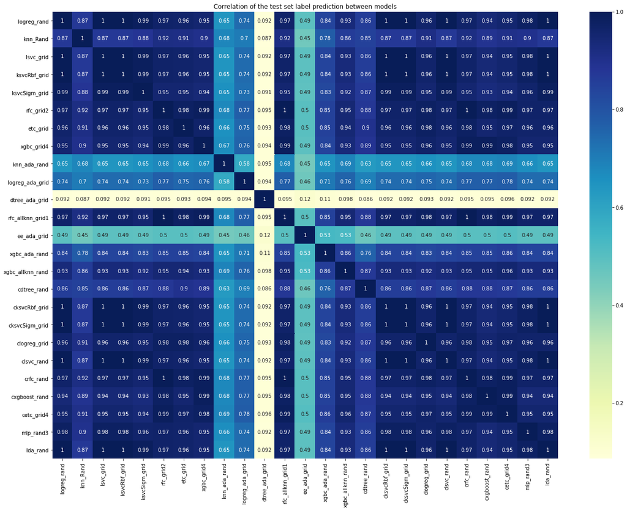

```python
# Create a prediction of all models on the test set
predictions_all = {}
for  key, value in total.items():
    # Get best estimator
    best_model = value.best_estimator_

    # Predict test labels
    predictions = best_model.predict(X_test)

    # Save predictions to a list
    predictions_all[key] = predictions
    # Creat a DataFrame for the predictions
pred = pd.DataFrame(predictions_all)
#pred.to_csv('pred_class.csv')
# Plot a heatmap of all correlations for easier visualization
fig, ax = plt.subplots(nrows=1, ncols=1, figsize=(22,16))
g = sns.heatmap(pred.corr(), annot=True, cmap='YlGnBu', ax=ax)
g.set_title('Correlation of the test set label prediction between models')
```

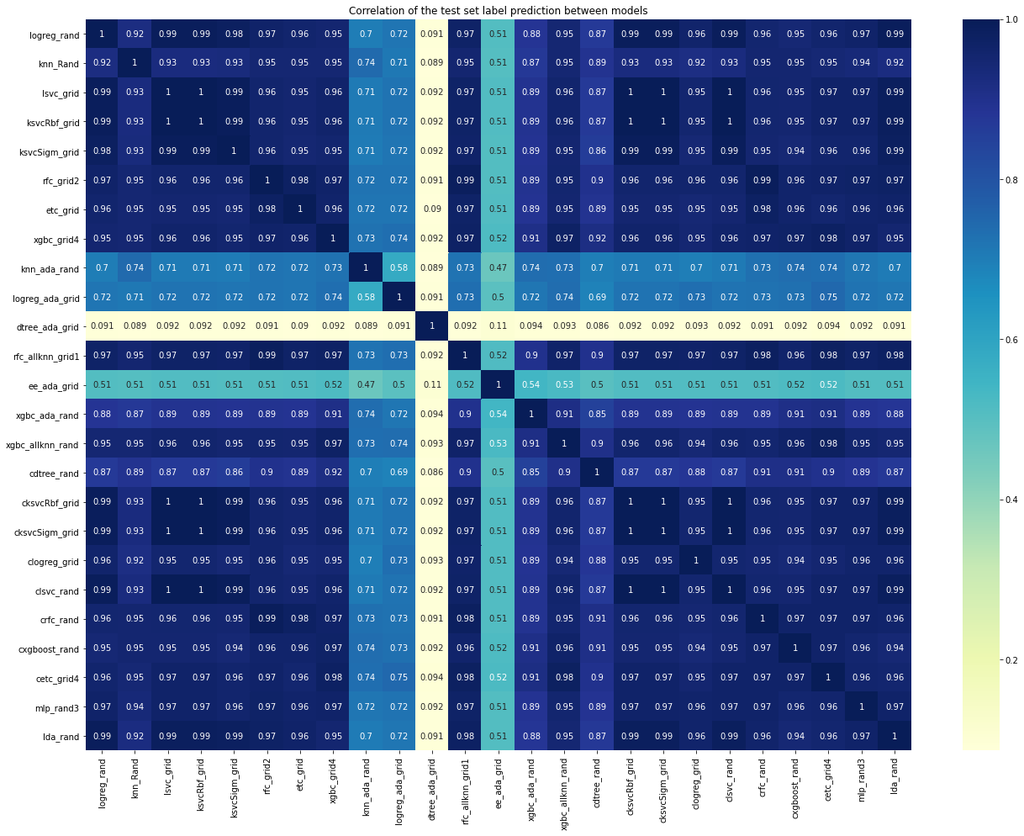

```python
# Create a prediction of all models on the test set
predictions_all = {}
for  key, value in total.items():
    # Get best estimator
    best_model = value.best_estimator_

    # Predict test labels
    predictions = best_model.predict(test)

    # Save predictions to a list
    predictions_all[key] = predictions
    # Creat a DataFrame for the predictions
pred = pd.DataFrame(predictions_all)
#pred.to_csv('pred_class.csv')
# Plot a heatmap of all correlations for easier visualization
fig, ax = plt.subplots(nrows=1, ncols=1, figsize=(22,16))
g = sns.heatmap(pred.corr(), annot=True, cmap='YlGnBu', ax=ax)
g.set_title('Correlation of the test set label prediction between models')
```

# Stacking

## stacking 5

```python
sclf5 = StackingClassifier(estimators=[
                            #   ('knn_Rand', knn_Rand.best_estimator_),
                            #    ('logreg_ada_grid', logreg_ada_grid.best_estimator_),
                             #     ('cdtree_rand',cdtree_rand.best_estimator_),
                           #      ('logreg_rand', logreg_rand.best_estimator_),
                             #  ('xgbc_allknn_rand',xgbc_allknn_rand.best_estimator_),
                               ('cetc_grid4',cetc_grid4.best_estimator_),
                             # ('rfc_allknn_grid1', rfc_allknn_grid1.best_estimator_),
                                  ( 'sclf4_grid.best_params_',sclf4_grid.best_estimator_),
                               ('cksvcSigm_grid	',cksvcSigm_grid.best_estimator_	),
                               ('crfc_rand',crfc_rand.best_estimator_)

                              ], final_estimator=xgbc_grid4.best_estimator_)
sclf1_param = {
              'final_estimator__max_depth' : [7,12,15],
              #'n_estimators' : [100,120,150],
             # final_estimator__learning_rate' : [.001,.05],
              # 'min_child_weight' : [1,3],
               # 'final_estimator__subsample':
               'final_estimator__reg_alpha' : [.2,.8]
             }
sclf5_grid = GridSearchCV(sclf5, sclf1_param,cv=5, return_train_score=True,scoring='f1' )
sclf5_grid.fit(X_train,y_train)
```

```
GridSearchCV(cv=5, error_score=nan,
             estimator=StackingClassifier(cv=None,
                                          estimators=[('cetc_grid4',
                                                       ExtraTreesClassifier(bootstrap=False,
                                                                            ccp_alpha=0.0,
                                                                            class_weight='balanced',
                                                                            criterion='gini',
                                                                            max_depth=8,
                                                                            max_features='log2',
                                                                            max_leaf_nodes=None,
                                                                            max_samples=None,
                                                                            min_impurity_decrease=0.0,
                                                                            min_impurity_split=None,
                                                                            min_samples_leaf=1,
                                                                            min_samples_split=2,
                                                                            min...
                                                                        reg_alpha=0.8,
                                                                        reg_lambda=1,
                                                                        scale_pos_weight=1,
                                                                        seed=None,
                                                                        silent=None,
                                                                        subsample=1,
                                                                        verbosity=1),
                                          n_jobs=None, passthrough=False,
                                          stack_method='auto', verbose=0),
             iid='deprecated', n_jobs=None,
             param_grid={'final_estimator__max_depth': [7, 12, 15],
                         'final_estimator__reg_alpha': [0.2, 0.8]},
             pre_dispatch='2*n_jobs', refit=True, return_train_score=True,
             scoring='f1', verbose=0)
```

```python
print(f'Best Mean Cross Validation Score is {sclf5_grid.best_score_}')
print(f'Best Parameters: {sclf5_grid.best_params_}')
print(f'Train score is {sclf5_grid.score(X_train,y_train)}')
print(f'Test score is {sclf5_grid.score(X_test,y_test)}')
print(f'Val score is {sclf5_grid.score(X_val,y_val)}')
```

```
Best Mean Cross Validation Score is 0.8836834723627176
Best Parameters: {'final_estimator__max_depth': 12, 'final_estimator__reg_alpha': 0.8}
Train score is 0.9857142857142858
Test score is 0.8421052631578947
Val score is 0.9052631578947369
```

```python
#sclf5_grid
pickle.dump( sclf5_grid, open( "/content/drive/My Drive/sclf5_grid.p", "wb" ) )
```

```python
sclf3 = StackingClassifier(estimators=
                              [
                               ('knn_Rand', knn_Rand.best_estimator_),
                            #    ('logreg_ada_grid', logreg_ada_grid.best_estimator_),
                                  ('cdtree_rand',cdtree_rand.best_estimator_),
                                 ('logreg_rand', logreg_rand.best_estimator_),
                             #  ('xgbc_allknn_rand',xgbc_allknn_rand.best_estimator_),
                               ('cetc_grid4',cetc_grid4.best_estimator_),
                             # ('rfc_allknn_grid1', rfc_allknn_grid1.best_estimator_),

                              ], final_estimator=xgbc_grid4.best_estimator_)
sclf1_param = {
             # 'final_estimator__C' : [.03,0.01],
              'stack_method':['auto', 'predict_proba']
             }
sclf4_grid = GridSearchCV(sclf3, sclf1_param,cv=5, return_train_score=True,scoring='f1' )
sclf4_grid.fit(X_train,y_train)
```

```
GridSearchCV(cv=5, error_score=nan,
             estimator=StackingClassifier(cv=None,
                                          estimators=[('knn_Rand',
                                                       KNeighborsClassifier(algorithm='auto',
                                                                            leaf_size=30,
                                                                            metric='minkowski',
                                                                            metric_params=None,
                                                                            n_jobs=None,
                                                                            n_neighbors=7,
                                                                            p=2,
                                                                            weights='distance')),
                                                      ('cdtree_rand',
                                                       DecisionTreeClassifier(ccp_alpha=0.0,
                                                                              class_weight={0: 1,
                                                                                            1: 1},
                                                                              criterion='gini',
                                                                              max_depth=8,
                                                                              max_feature...
                                                                        objective='binary:logistic',
                                                                        random_state=42,
                                                                        reg_alpha=0.8,
                                                                        reg_lambda=1,
                                                                        scale_pos_weight=1,
                                                                        seed=None,
                                                                        silent=None,
                                                                        subsample=1,
                                                                        verbosity=1),
                                          n_jobs=None, passthrough=False,
                                          stack_method='auto', verbose=0),
             iid='deprecated', n_jobs=None,
             param_grid={'stack_method': ['auto', 'predict_proba']},
             pre_dispatch='2*n_jobs', refit=True, return_train_score=True,
             scoring='f1', verbose=0)
```

```python
print(f'Best Mean Cross Validation Score is {sclf4_grid.best_score_}')
print(f'Best Parameters: {sclf4_grid.best_params_}')
print(f'Train score is {sclf4_grid.score(X_train,y_train)}')
print(f'Test score is {sclf4_grid.score(X_test,y_test)}')
print(f'Val score is {sclf4_grid.score(X_val,y_val)}')
```

```
Best Mean Cross Validation Score is 0.8880752145458027
Best Parameters: {'stack_method': 'auto'}
Train score is 0.9420289855072463
Test score is 0.8367346938775511
Val score is 0.9183673469387755
```

```python
pickle.dump( sclf4_grid, open( "/content/drive/My Drive/sclf4_grid.p", "wb" ) )
```

## stacking 4

```python
sclf4 = StackingClassifier(estimators=
                              [
                               ('lda_rand', lda_rand.best_estimator_),
                                ('ksvcRbf_grid', ksvcRbf_grid.best_estimator_),
                                  ('cdtree_rand',cdtree_rand.best_estimator_),
                                 ('logreg_rand', logreg_rand.best_estimator_),
                              ('crfc_rand', crfc_rand.best_estimator_),


                              ], final_estimator=cetc_grid4.best_estimator_)
sclf1_param = {
                      # 'final_estimator__C' : [.03,0.01],
                  #     'stack_method':['auto', 'predict_proba']
                            'final_estimator__n_estimators': [200,300,400],
              'final_estimator__max_features': [ 'log2'],
              'final_estimator__max_depth' : [7,8,12],
              #'criterion' :['gini'],
              'final_estimator__class_weight': ['balanced']}

sclf4_grid = GridSearchCV(sclf4, sclf1_param,cv=5, return_train_score=True,scoring='f1' )
sclf4_grid.fit(X_train,y_train)
```

```
GridSearchCV(cv=5, error_score=nan,
             estimator=StackingClassifier(cv=None,
                                          estimators=[('lda_rand',
                                                       LinearDiscriminantAnalysis(n_components=None,
                                                                                  priors=None,
                                                                                  shrinkage=0.0023752258796568347,
                                                                                  solver='lsqr',
                                                                                  store_covariance=False,
                                                                                  tol=1e-05)),
                                                      ('ksvcRbf_grid',
                                                       SVC(C=10,
                                                           break_ties=False,
                                                           cache_size=200,
                                                           class_weight=None,
                                                           coef0=0.0,
                                                           decision_function_shape='ovr',
                                                           de...
                                          n_jobs=None, passthrough=False,
                                          stack_method='auto', verbose=0),
             iid='deprecated', n_jobs=None,
             param_grid={'final_estimator__class_weight': ['balanced'],
                         'final_estimator__max_depth': [7, 8, 12],
                         'final_estimator__max_features': ['log2'],
                         'final_estimator__n_estimators': [200, 300, 400]},
             pre_dispatch='2*n_jobs', refit=True, return_train_score=True,
             scoring='f1', verbose=0)
```

```python
print(f'Best Mean Cross Validation Score is {sclf4_grid.best_score_}')
print(f'Best Parameters: {sclf4_grid.best_params_}')
print(f'Train score is {sclf4_grid.score(X_train,y_train)}')
print(f'Test score is {sclf4_grid.score(X_test,y_test)}')
print(f'Val score is {sclf4_grid.score(X_val,y_val)}')
```

```
Best Mean Cross Validation Score is 0.8720958985109929
Best Parameters: {'final_estimator__class_weight': 'balanced', 'final_estimator__max_depth': 12, 'final_estimator__max_features': 'log2', 'final_estimator__n_estimators': 400}
Train score is 0.9754385964912281
Test score is 0.8210526315789474
Val score is 0.8749999999999999
```

```python
pickle.dump( sclf4_grid, open( "/content/drive/My Drive/sclf5_grid.p", "wb" ) )
```

## Stacking 1

https://towardsdatascience.com/stacking-made-easy-with-sklearn-e27a0793c92b

```python
from sklearn.ensemble import StackingClassifier
```

```python
sclf1 = StackingClassifier(estimators=
                              [
                                  ('rfc_allknn_grid2', rfc_allknn_grid2.best_estimator_),
                                  ('cetc_grid', cetc_grid.best_estimator_),
                               ('rfc_ada_rand',rfc_ada_rand.best_estimator_),
                               ('cxgboost_rand', cxgboost_rand.best_estimator_),
                             #  ('gbc_grid', gbc_grid.best_estimator_),

                              ], final_estimator=LogisticRegression())
sclf1_param = {
              'final_estimator__C' : [0.1,0.2],
              'stack_method':['auto', 'predict_proba']
             }
sclf1_grid = GridSearchCV(sclf1, sclf1_param,cv=5, return_train_score=True,scoring='f1' )
sclf1_grid.fit(X_train,y_train)
```

```python
print(f'Best Mean Cross Validation Score is {sclf1_grid.best_score_}')
print(f'Best Parameters: {sclf1_grid.best_params_}')
print(f'Train score is {sclf1_grid.score(X_train,y_train)}')
print(f'Test score is {sclf1_grid.score(X_test,y_test)}')
print(f'Val score is {sclf1_grid.score(X_val,y_val)}')
```

```
Best Mean Cross Validation Score is 0.8729163733869617
Best Parameters: {'final_estimator__C': 0.2, 'stack_method': 'auto'}
Train score is 0.9477611940298507
Test score is 0.8421052631578947
Val score is 0.888888888888889
```

```python
pickle.dump( sclf1_grid, open( "/content/drive/My Drive/sclf1_grid.p", "wb" ) )
```

```python
sclf1_grid = pickle.load( open( "/content/drive/My Drive/sclf1_grid.p", "rb" ) )
```

# predictions

```python
# Create a prediction of all models on the test set
predictions_all = {}
for  key, value in classifiers.items():
    # Get best estimator
    best_model = value.best_estimator_

    # Predict test labels
    predictions = best_model.predict(X_test)

    # Save predictions to a list
    predictions_all[key] = predictions
```

```python
test2 = pd.read_csv('/content/drive/My Drive/test.csv')
```

```python
# Preprocessing of validation data, get predictions
test_data_labels = cetc_grid4.predict(test)

# Create predictions to be submitted!
pd.DataFrame({'Id': test2.Id, 'Target': test_data_labels}).to_csv(' predict_cetc_grid4.csv', index =False)
print("Done :D")
```

```
Done :D
```

# creating new datasets with diff preprocessing

```python
data = pd.read_csv('/content/drive/My Drive/project 2/train.csv')
test = pd.read_csv('/content/drive/My Drive/test.csv')
test1 = pd.read_csv('/content/drive/My Drive/test.csv')
data.head()
```

|  | Id | V1 | V2 | V3 | V4 | V5 | V6 | V7 | V8 | V9 | V10 | V11 | V12 | V13 | V14 | V15 | V16 | V17 | V18 | V19 | V20 | V21 | V22 | V23 | V24 | V25 | V26 | V27 | V28 | … |
| --- | --- | --- | --- | --- | --- | --- | --- | --- | --- | --- | --- | --- | --- | --- | --- | --- | --- | --- | --- | --- | --- | --- | --- | --- | --- | --- | --- | --- | --- | --- |
| 0 | 138662 | -0.711273 | 1.272483 | 1.681631 | 0.039897 | -0.312381 | -1.161083 | 0.853875 | -0.173979 | -0.438558 | -0.053805 | 0.321036 | 0.814690 | 1.226450 | -0.152389 | 0.687480 | -0.030825 | -0.284477 | -0.696867 | -0.227419 | 0.298008 | -0.208181 | -0.414631 | 0.057957 | 0.930321 | -0.165598 | 0.038799 | 0.384295 | 0.192762 | … |
| 1 | 235999 | 1.990679 | -0.128465 | -1.700556 | 0.529839 | 0.136889 | -1.404270 | 0.593353 | -0.456700 | 0.648260 | -0.071353 | -0.982339 | 0.229658 | -0.592959 | 0.574159 | -0.263545 | -0.780886 | -0.066039 | -0.575168 | 0.227544 | -0.205092 | 0.018179 | 0.179084 | -0.004248 | 0.039531 | 0.333765 | -0.225201 | -0.047285 | -0.059682 | … |
| 2 | 245376 | 1.812653 | -0.476162 | -0.338988 | 1.386750 | -0.745965 | -0.449870 | -0.492226 | 0.029904 | 1.129394 | 0.227346 | -1.197477 | -0.555129 | -1.369130 | 0.320282 | 1.002745 | 0.501765 | -0.670053 | 0.478236 | -0.820942 | -0.202894 | 0.252668 | 0.655719 | 0.090057 | -0.136884 | -0.172452 | -0.556921 | 0.036490 | -0.021575 | … |
| 3 | 202483 | -1.014219 | 0.522775 | -0.337978 | -1.957797 | 3.578395 | 3.266965 | 0.602857 | 0.644645 | -0.305879 | -0.417906 | 0.010333 | -0.299630 | -0.379164 | 0.329193 | 0.957904 | -0.417285 | -0.705683 | -0.063235 | -0.381035 | 0.136061 | 0.147742 | 0.590740 | -0.680551 | 0.745346 | 1.119496 | 0.013520 | 0.004530 | -0.132643 | … |
| 4 | 9710 | -0.967270 | -0.053815 | 2.273463 | -0.894434 | 0.728924 | 0.153524 | -0.038330 | 0.165252 | 1.172526 | -0.879114 | 2.505831 | -2.249565 | 0.791677 | 1.546279 | -0.133370 | 0.184501 | 0.307080 | -0.081722 | -1.359941 | 0.007512 | 0.106692 | 0.514430 | -0.081546 | -0.305042 | -0.354883 | 0.896254 | -0.182293 | -0.142810 | … |

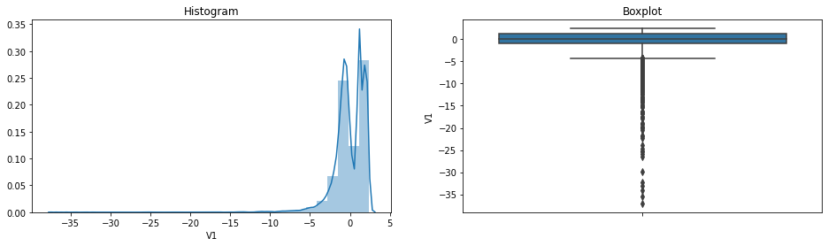

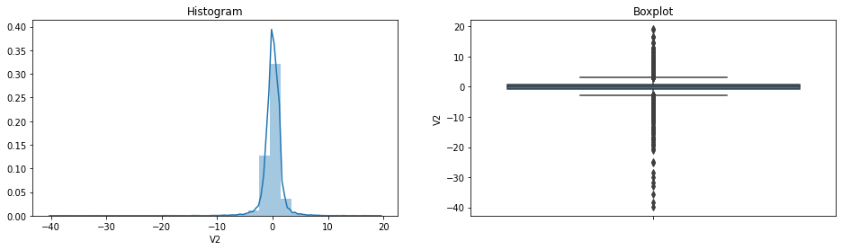

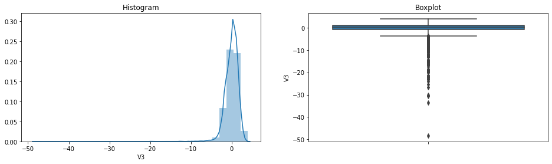

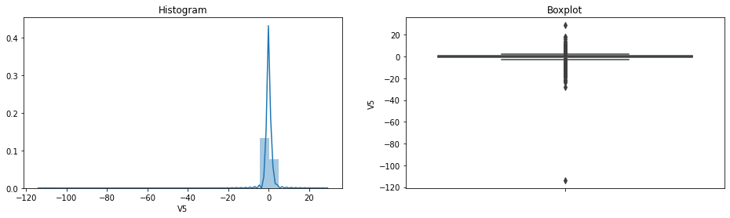

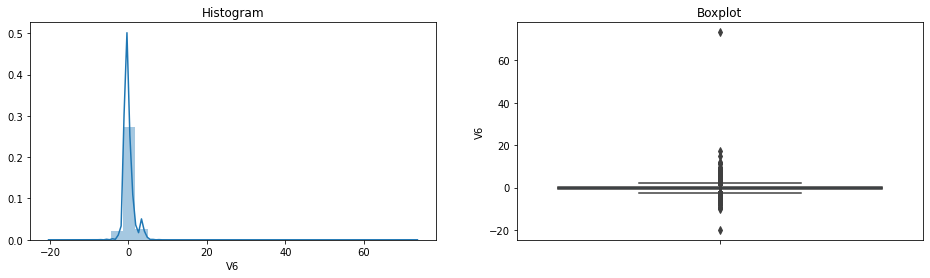

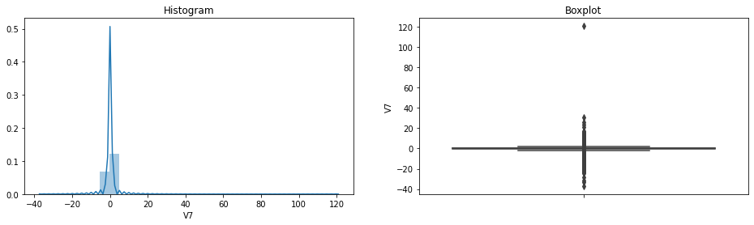

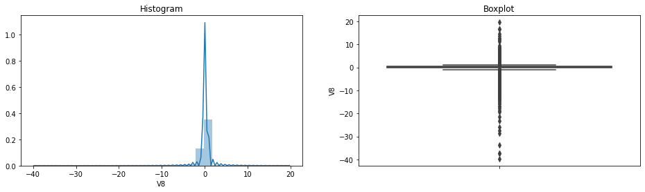

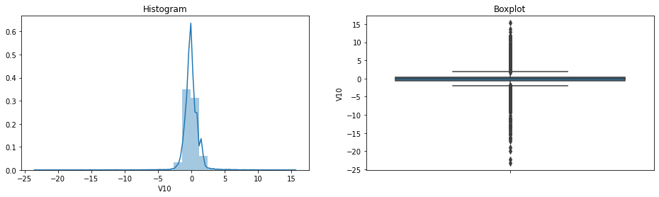

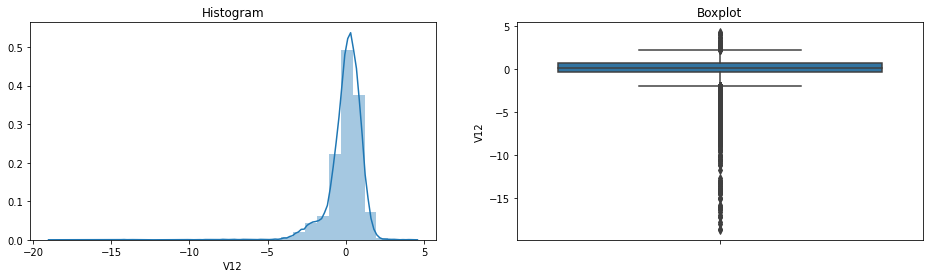

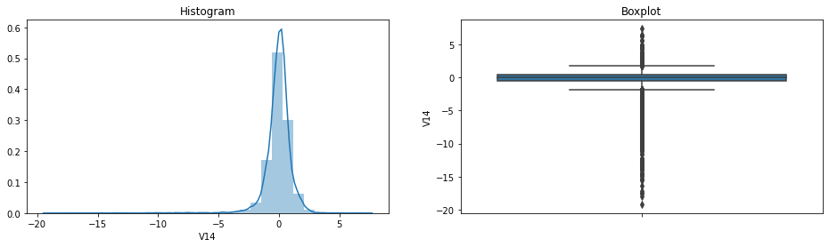

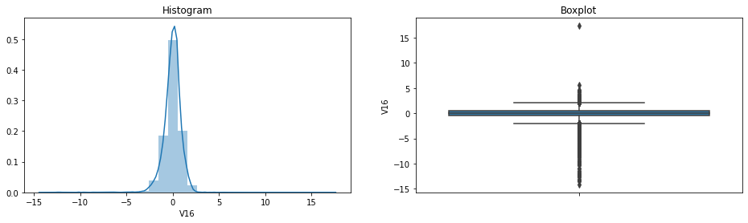

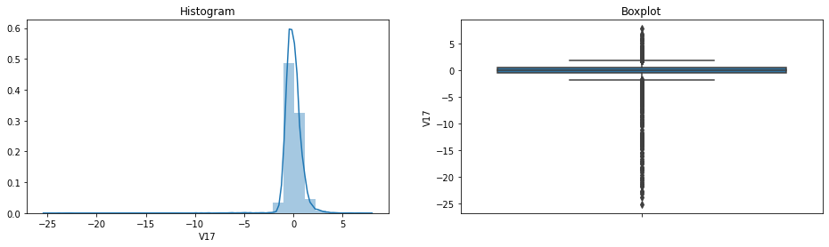

[8 more figures not shown]

```python
# Use the above function for visualizing numerical variables

for var in continuous:
    diagnostic_plots(data, var)
```